# Part 1 — Annotation descriptives

### By full-author-list gender composition

Every paper’s authors, sorted into one of five groups: solo female author, solo male author, an all-female team, an all-male team, or a mixed-gender team. Solo authorship is kept separate from team composition, so a single author’s gender isn’t treated as if it were a team’s composition.

**Plot**

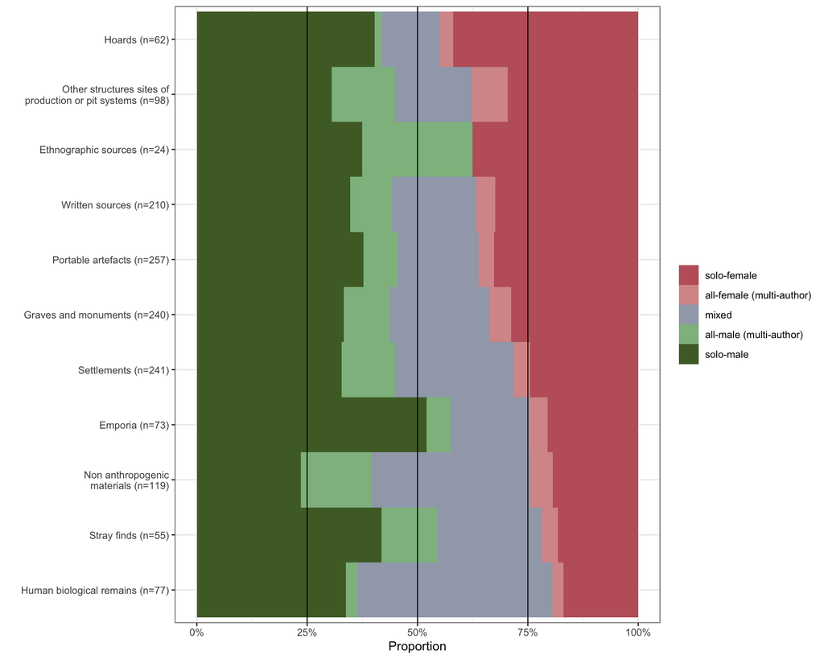

**Table**

| source | papers | solo-female | all-female (multi-author) | mixed | all-male (multi-author) | solo-male |
| --- | --- | --- | --- | --- | --- | --- |
| Hoards | 62 | 26 (42%) | 2 (3%) | 8 (13%) | 1 (2%) | 25 (40%) |
| Other structures sites of production or pit systems | 98 | 29 (30%) | 8 (8%) | 17 (17%) | 14 (14%) | 30 (31%) |
| Ethnographic sources | 24 | 9 (38%) | 0 (0%) | 0 (0%) | 6 (25%) | 9 (38%) |
| Written sources | 210 | 68 (32%) | 9 (4%) | 40 (19%) | 20 (10%) | 73 (35%) |
| Portable artefacts | 257 | 84 (33%) | 9 (4%) | 47 (18%) | 20 (8%) | 97 (38%) |
| Graves and monuments | 240 | 69 (29%) | 12 (5%) | 54 (22%) | 25 (10%) | 80 (33%) |
| Settlements | 241 | 59 (24%) | 9 (4%) | 65 (27%) | 29 (12%) | 79 (33%) |
| Emporia | 73 | 15 (21%) | 3 (4%) | 13 (18%) | 4 (5%) | 38 (52%) |
| Non anthropogenic materials | 119 | 23 (19%) | 6 (5%) | 43 (36%) | 19 (16%) | 28 (24%) |
| Stray finds | 55 | 10 (18%) | 2 (4%) | 13 (24%) | 7 (13%) | 23 (42%) |
| Human biological remains | 77 | 13 (17%) | 2 (3%) | 34 (44%) | 2 (3%) | 26 (34%) |

### Mixed-gender authorship only

**Plot**

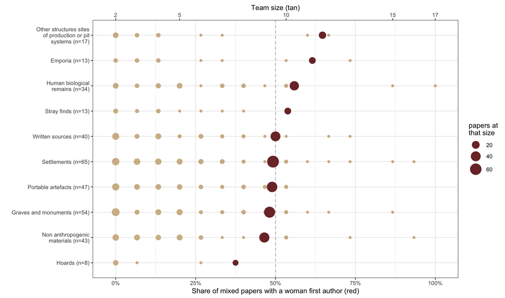

Each source of evidence has two overlaid series on the same row, using different x-axes. Red dots (bottom axis): share of that source’s mixed-gender papers with a woman first author, dot size is the number of mixed papers behind that source. Tan dots (top axis): every distinct author-team size found among that source’s mixed papers, dot size is how many papers have that size. Dashed vertical line marks 50% on the red (bottom) axis only.

**Table**

The plot’s numbers, top row first. The interval is the Wilson 95% interval on the share of that source’s mixed-gender papers with a woman first author. Team size is the number of authors per paper.

| source | mixed papers | woman first | % woman first | Wilson 95% low (%) | Wilson 95% high (%) | median team size | smallest team | largest team |
| --- | --- | --- | --- | --- | --- | --- | --- | --- |
| Other structures sites of production or pit systems | 17 | 11 | 64.7 | 41.3 | 82.7 | 3 | 2 | 12 |
| Emporia | 13 | 8 | 61.5 | 35.5 | 82.3 | 4 | 2 | 13 |
| Human biological remains | 34 | 19 | 55.9 | 39.5 | 71.1 | 5 | 2 | 17 |
| Stray finds | 13 | 7 | 53.8 | 29.1 | 76.8 | 4 | 2 | 8 |
| Written sources | 40 | 20 | 50.0 | 35.2 | 64.8 | 4 | 2 | 13 |
| Settlements | 65 | 32 | 49.2 | 37.5 | 61.1 | 4 | 2 | 16 |
| Portable artefacts | 47 | 23 | 48.9 | 35.3 | 62.8 | 4 | 2 | 10 |
| Graves and monuments | 54 | 26 | 48.1 | 35.4 | 61.1 | 4 | 2 | 15 |
| Non anthropogenic materials | 43 | 20 | 46.5 | 32.5 | 61.1 | 4 | 2 | 16 |
| Hoards | 8 | 3 | 37.5 | 13.7 | 69.4 | 2 | 2 | 6 |

## Correspondence analysis

Correspondence analysis places the Topic, Method and Source of evidence categories and the individual papers on shared axes. The input holds one row per paper and one column per category, coded 1 when the paper carries a value for the category (Primary or Secondary) and 0 otherwise. Categories that sit close together on the map appear on similar sets of papers, and papers that sit close together carry similar sets of categories. Author gender and publication year take no part in the analysis; they colour the paper points afterwards.

### Inertia

Each dimension accounts for a share of the total inertia. The plot shows that share for the first 15 dimensions. The table covers the first 10, one row per dimension in order, with the eigenvalue, the percentage of inertia and the cumulative percentage.

**Plot**

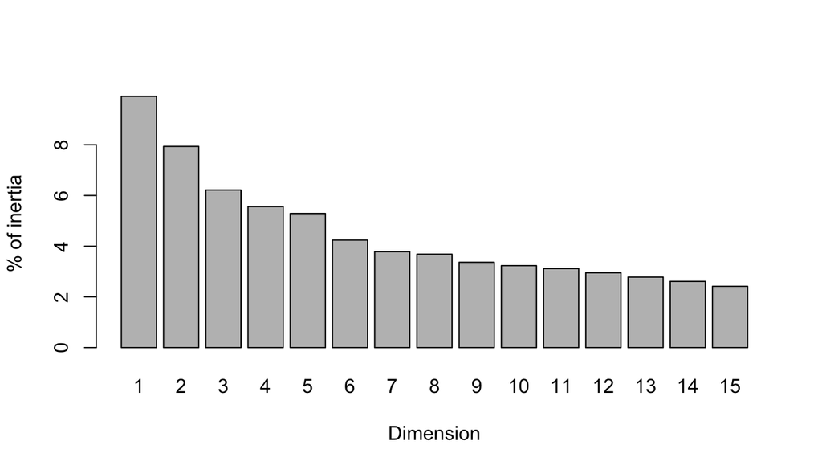

Percentage of inertia on each of the first 15 dimensions.

**Table**

The plot’s numbers for the first 10 dimensions, with the eigenvalue and the cumulative percentage added.

| eigenvalue | percent | cumulative |
| --- | --- | --- |
| 0.20 | 9.91 | 9.91 |
| 0.16 | 7.94 | 17.85 |
| 0.13 | 6.22 | 24.06 |
| 0.11 | 5.56 | 29.62 |
| 0.11 | 5.29 | 34.91 |
| 0.09 | 4.24 | 39.16 |
| 0.08 | 3.78 | 42.94 |
| 0.08 | 3.69 | 46.63 |
| 0.07 | 3.37 | 49.99 |
| 0.07 | 3.23 | 53.23 |

### What drives each axis

A category’s contribution to a dimension is its share of that dimension’s inertia, in percent, and the contributions sum to 100 per dimension. The first two tabs list the ten categories that contribute most to dimension 1 and to dimension 2, with the category’s block (group), its number of papers (n), its coordinate (dim) and its contribution (ctr). The last two tabs list the five papers with the lowest and the five with the highest coordinate on each dimension, lowest first.

**Categories, dimension 1**

| label | group | n | dim1 | ctr1 |
| --- | --- | --- | --- | --- |
| Outfield resources | Topics | 58 | 1.09 | 6.72 |
| Human biological remains | Sources of Evidence | 77 | -0.95 | 6.71 |
| Biological analyses | Methods | 40 | -1.25 | 6.05 |
| Gender | Topics | 97 | -0.77 | 5.56 |
| Geochemical analyses | Methods | 22 | 1.43 | 4.35 |
| Rituals | Topics | 139 | -0.57 | 4.34 |
| Violence | Topics | 106 | -0.65 | 4.31 |
| Absolute dating | Methods | 119 | 0.61 | 4.25 |
| Geophysical analyses | Methods | 37 | 1.08 | 4.22 |
| Worldviews | Topics | 159 | -0.52 | 4.17 |

**Categories, dimension 2**

| label | group | n | dim2 | ctr2 |
| --- | --- | --- | --- | --- |
| Palaeoenvironment reconstruction | Methods | 76 | 1.24 | 14.20 |
| Stable isotope analysis | Methods | 51 | 1.47 | 13.42 |
| Human biological remains | Sources of Evidence | 77 | 1.10 | 11.31 |
| Non anthropogenic materials | Sources of Evidence | 119 | 0.83 | 10.00 |
| aDNA | Methods | 16 | 1.88 | 6.85 |
| Hoards | Sources of Evidence | 62 | -0.89 | 5.97 |
| Hunting | Topics | 39 | 1.05 | 5.17 |
| Biological analyses | Methods | 40 | 1.02 | 5.08 |
| Outfield resources | Topics | 58 | 0.73 | 3.79 |
| Worldviews | Topics | 159 | -0.35 | 2.41 |

**Papers, dimension 1**

| cite_key | dim1 |
| --- | --- |
| reiter2019interpreting | -1.09 |
| toplak2015prone | -1.09 |
| toplak2017deviant | -1.00 |
| androshchuk2018female | -0.98 |
| andren2006old | -0.97 |
| bill2017heimdalsjordet | 0.90 |
| devos2013soil | 0.90 |
| milek2013integrated | 0.95 |
| wouters2016soil | 1.01 |
| henriksen2014first | 1.17 |

**Papers, dimension 2**

| cite_key | dim2 |
| --- | --- |
| feveile2015metaldetektorproblematikken | -0.83 |
| feveile2017ombukkede | -0.71 |
| neiss2016new | -0.67 |
| lund2020rune | -0.67 |
| oehrl2017documenting | -0.65 |
| star2017ancient | 1.24 |
| krzewinska2018genomic | 1.28 |
| frei2012strontium | 1.47 |
| leslie2015fine | 1.49 |
| price2014peopling | 1.50 |

### Maps

Each map plots the first two dimensions, and each axis label gives the percentage of inertia the dimension holds. The Categories tab sizes each point by its number of papers and colours it by block. The next two tabs plot the papers, coloured by author gender and by publication year. The last tab gives the size of each gender group.

**Categories**

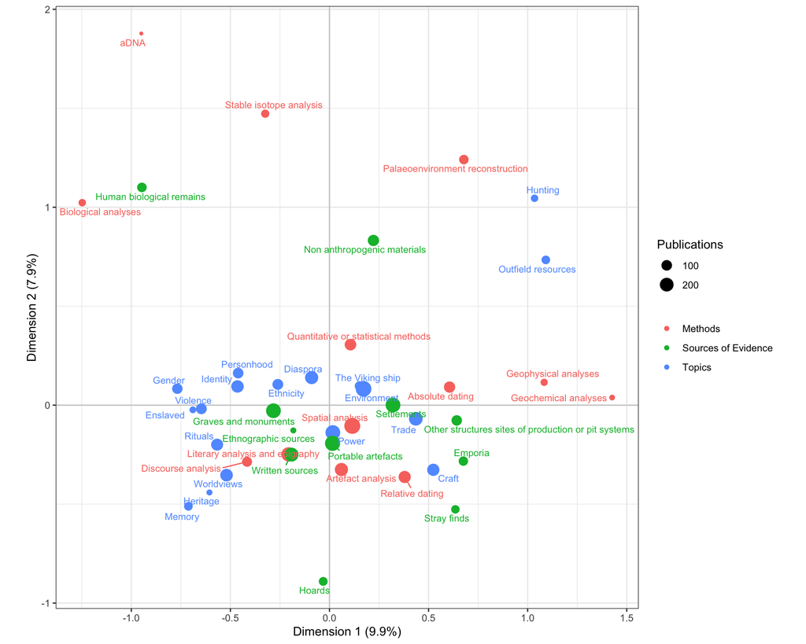

Categories on the first two dimensions, coloured by block (Topics, Sources of Evidence, Methods) and sized by the number of papers that carry them.

**Papers by gender**

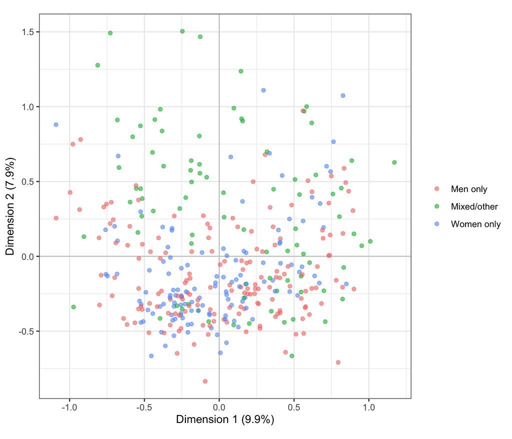

Papers on the first two dimensions, coloured by author gender: all women, all men, or mixed or other. Papers with no author gender recorded appear in grey.

**Papers by year**

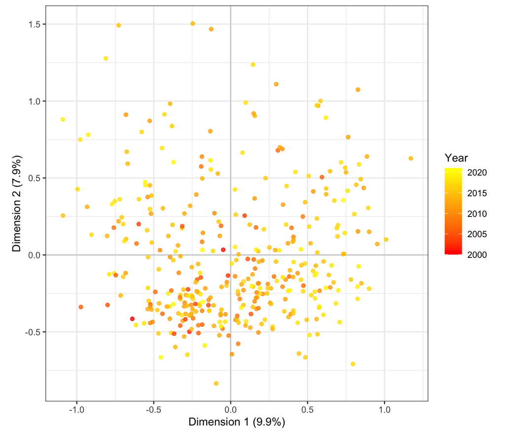

Papers on the first two dimensions, coloured by publication year, from red (earliest) to yellow (latest).

**Table, papers by gender**

The number of papers in each author gender group on the gender map.

| authorship | papers |
| --- | --- |
| Men only | 163 |
| Mixed/other | 85 |
| Women only | 121 |

### Quality of representation

Quality of representation measures, for each category, how much of its departure from the average the first two dimensions capture, which is how much of it the maps above show. Values near 1 mean the position on the map is accurate. Values near 0 mean that other dimensions define what makes the category distinctive, so its plotted position can mislead. A value of 0.3–0.6 is well represented. A value of 0.1–0.25 is partly represented; read it as a tendency. A value under 0.05 is barely represented, and a label near the origin then means the category does not separate along the first two dimensions.

Point size on the map below shows quality of representation in place of the paper counts used above. Transparency made quality hard to read, and adding the counts as well would crowd the plot.

**Plot**

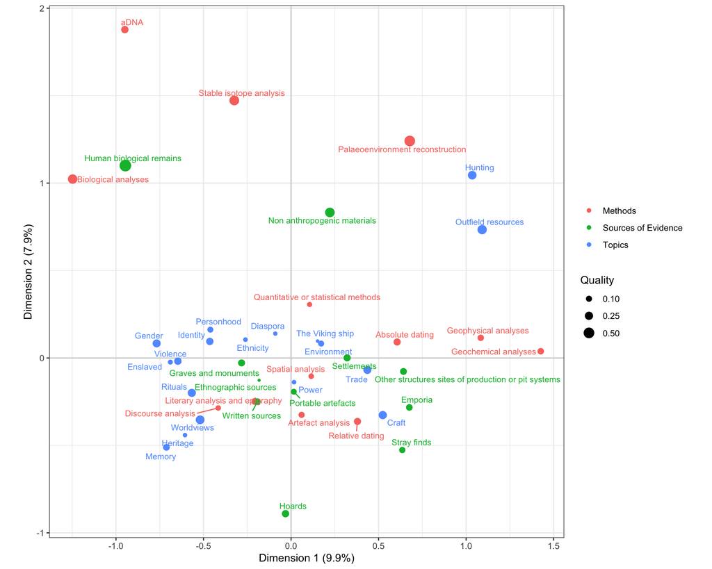

Categories on the first two dimensions, coloured by block and sized by quality of representation (0 to 1).

**Table, quality**

Quality of representation for every category, highest first.

|  | quality of representation |
| --- | --- |
| Human biological remains | 0.63 |
| Palaeoenvironment reconstruction | 0.50 |
| Stable isotope analysis | 0.40 |
| Non anthropogenic materials | 0.38 |
| Biological analyses | 0.37 |
| Outfield resources | 0.35 |
| Worldviews | 0.30 |
| Hunting | 0.29 |
| Craft | 0.25 |
| Rituals | 0.25 |
| Gender | 0.23 |
| Trade | 0.23 |
| Violence | 0.18 |
| aDNA | 0.18 |
| Identity | 0.18 |
| Hoards | 0.17 |
| Absolute dating | 0.17 |
| Settlements | 0.16 |
| Relative dating | 0.16 |
| Graves and monuments | 0.15 |
| Literary analysis and epigraphy | 0.15 |
| Other structures sites of production or pit systems | 0.15 |
| Memory | 0.14 |
| Written sources | 0.14 |
| Emporia | 0.13 |
| Geochemical analyses | 0.13 |
| Geophysical analyses | 0.12 |
| Stray finds | 0.11 |
| Artefact analysis | 0.10 |
| Environment | 0.10 |
| Personhood | 0.09 |
| Portable artefacts | 0.09 |
| Spatial analysis | 0.07 |
| Discourse analysis | 0.07 |
| Quantitative or statistical methods | 0.06 |
| Enslaved | 0.05 |
| Ethnicity | 0.04 |
| Power | 0.04 |
| Heritage | 0.03 |
| Diaspora | 0.03 |
| The Viking ship | 0.01 |
| Ethnographic sources | 0.00 |

**Table, categories**

Every category with its block, its number of papers, its quality of representation and its contribution to dimension 1 and dimension 2.

| label | group | n | qlt | ctr1 | ctr2 |
| --- | --- | --- | --- | --- | --- |
| Trade | Topics | 199 | 0.23 | 3.67 | 0.11 |
| Diaspora | Topics | 179 | 0.03 | 0.14 | 0.42 |
| Gender | Topics | 97 | 0.23 | 5.56 | 0.08 |
| Identity | Topics | 154 | 0.18 | 3.23 | 0.17 |
| Violence | Topics | 106 | 0.18 | 4.31 | 0.00 |
| Ethnicity | Topics | 107 | 0.04 | 0.71 | 0.14 |
| Enslaved | Topics | 31 | 0.05 | 1.43 | 0.00 |
| Power | Topics | 239 | 0.04 | 0.01 | 0.56 |
| Worldviews | Topics | 159 | 0.30 | 4.17 | 2.41 |
| Personhood | Topics | 101 | 0.09 | 2.09 | 0.32 |
| Environment | Topics | 279 | 0.10 | 0.80 | 0.23 |
| The Viking ship | Topics | 78 | 0.01 | 0.17 | 0.09 |
| Rituals | Topics | 139 | 0.25 | 4.34 | 0.67 |
| Memory | Topics | 59 | 0.14 | 2.91 | 1.87 |
| Craft | Topics | 148 | 0.25 | 3.95 | 1.92 |
| Outfield resources | Topics | 58 | 0.35 | 6.72 | 3.79 |
| Hunting | Topics | 39 | 0.29 | 4.06 | 5.17 |
| Graves and monuments | Sources of Evidence | 240 | 0.15 | 1.87 | 0.02 |
| Hoards | Sources of Evidence | 62 | 0.17 | 0.01 | 5.97 |
| Settlements | Sources of Evidence | 241 | 0.16 | 2.41 | 0.00 |
| Emporia | Sources of Evidence | 73 | 0.13 | 3.24 | 0.71 |
| Other structures sites of production or pit systems | Sources of Evidence | 98 | 0.15 | 3.93 | 0.07 |
| Portable artefacts | Sources of Evidence | 257 | 0.09 | 0.01 | 1.16 |
| Human biological remains | Sources of Evidence | 77 | 0.63 | 6.71 | 11.31 |
| Non anthropogenic materials | Sources of Evidence | 119 | 0.38 | 0.57 | 10.00 |
| Stray finds | Sources of Evidence | 55 | 0.11 | 2.16 | 1.85 |
| aDNA | Methods | 16 | 0.18 | 1.40 | 6.85 |
| Biological analyses | Methods | 40 | 0.37 | 6.05 | 5.08 |
| Palaeoenvironment reconstruction | Methods | 76 | 0.50 | 3.40 | 14.20 |
| Stable isotope analysis | Methods | 51 | 0.40 | 0.52 | 13.42 |
| Absolute dating | Methods | 119 | 0.17 | 4.25 | 0.12 |
| Geophysical analyses | Methods | 37 | 0.12 | 4.22 | 0.06 |
| Geochemical analyses | Methods | 22 | 0.13 | 4.35 | 0.00 |
| Spatial analysis | Methods | 292 | 0.07 | 0.38 | 0.39 |
| Artefact analysis | Methods | 180 | 0.10 | 0.06 | 2.31 |
| Literary analysis and epigraphy | Methods | 220 | 0.15 | 0.91 | 1.65 |
| Quantitative or statistical methods | Methods | 128 | 0.06 | 0.14 | 1.45 |
| Discourse analysis | Methods | 87 | 0.07 | 1.46 | 0.86 |
| Heritage | Topics | 24 | 0.03 | 0.86 | 0.57 |
| Written sources | Sources of Evidence | 210 | 0.14 | 0.75 | 1.59 |
| Relative dating | Methods | 146 | 0.16 | 2.04 | 2.33 |
| Ethnographic sources | Sources of Evidence | 24 | 0.00 | 0.08 | 0.05 |

## Region

Region is the one annotation field the coder fills in from the study’s own keywords, so it is free text and may be blank (see the codebook). The sections below turn it into places. The terms they use (region token, canonical token, matched place, override, macro-region, country, super-region), the columns of the lookup file, the stages that produce it and the known issues are defined in `analysis/region_matching/README.md`.

**Plot**

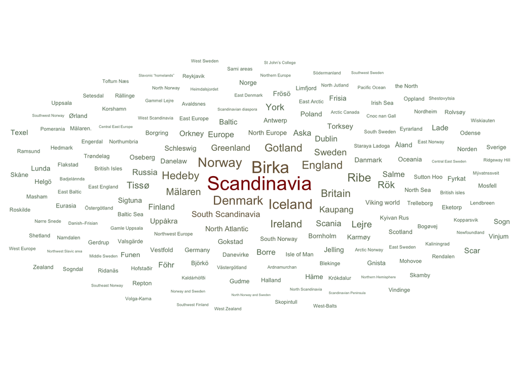

**Table**

The word cloud’s numbers: every entry of the Region field as typed, before spelling variants are folded, with the number of times it appears.

| region field entry | mentions |
| --- | --- |
| Scandinavia | 63 |
| Birka | 20 |
| Denmark | 17 |
| Iceland | 17 |
| Norway | 16 |
| South Scandinavia | 15 |
| England | 13 |
| Gotland | 11 |
| Hedeby | 11 |
| Mälaren | 9 |
| Britain | 8 |
| Greenland | 8 |
| Ireland | 8 |
| Kaupang | 7 |
| North Atlantic | 7 |
| Ribe | 7 |
| Sweden | 7 |
| North Europe | 5 |
| Schleswig | 5 |
| Europe | 4 |
| Finland | 4 |
| Russia | 4 |
| Scania | 4 |
| South Norway | 4 |
| Tissø | 4 |
| Uppåkra | 4 |
| Viking world | 4 |
| Bornholm | 3 |
| Danelaw | 3 |
| Danmark | 3 |

[output cut: 158 more lines]

### Matching to Wikidata

The matching does not run in this document. It is a script in `analysis/region_matching/`, run by hand when the lookup needs building or refreshing. This document `source()`s the script for its definitions, so the override table, the macro-region lists and the super-region map are each defined once, there, and reads `analysis/region_matching/region_lookup.csv`, which the script writes, the same way Topic, Method, and Source read their own derived data. Why Wikidata, and how to run the stages, are in the README.

What is applied when the file is read, as defined in the script:

**Overrides**

Tokens whose automatic match was a same-named place elsewhere. The coordinate and label shown replace the match.

| region_token | wikidata_qid | normalized_label | lat | lon | place_type | country |
| --- | --- | --- | --- | --- | --- | --- |
| East Norway | Q216065 | Eastern Norway (Østlandet) | 60.25000 | 10.67000 | region | NA |
| Repton | Q1018787 | Repton | 52.83983 | -1.55061 | village | NA |
| Baltic | Q545 | Baltic Sea | 58.00000 | 20.00000 | sea | NA |
| North Norway | Q214041 | Northern Norway | 69.66700 | 19.00000 | region | NA |
| Scotland | Q22 | Scotland | 56.00000 | -4.00000 | country | NA |
| Masham | Q2330678 | Masham | 54.22000 | -1.65600 | town | NA |
| West Sweden | Q4992082 | West Sweden (Västsverige) | 57.55800 | 12.60200 | region | NA |
| East Denmark | Q131281582 | Eastern Denmark (general, administrative region est. 2027) | 55.44000 | 11.56000 | region | NA |
| Britain | Q145 | United Kingdom | NA | NA | NA | United Kingdom |

**Macro-regions**

Tokens that are kept off the map. “area” terms name an area, or part of a country, that no single point or country represents, so they also have no country and no super-region. “country name” terms are matched correctly but are country-sized: they keep their country and super-region, so a paper tagged only with one of them counts in the by-country and by-super-region views below.

| kind | token | papers |
| --- | --- | --- |
| area | Scandinavia | 63 |
| area | South Scandinavia | 15 |
| area | North Atlantic | 7 |
| area | North Europe | 5 |
| area | Europe | 4 |
| area | South Norway | 4 |
| area | Viking world | 4 |
| area | Northwest Europe | 3 |
| area | British Isles | 2 |
| area | East Europe | 2 |
| area | Oceania | 2 |
| area | Scandinavian diaspora | 2 |
| area | South Sweden | 2 |
| area | West Scandinavia | 2 |
| area | Arctic Canada | 1 |
| area | Arctic Norway | 1 |
| area | British isles | 1 |
| area | Central East Europe | 1 |
| area | Central East Sweden | 1 |
| area | East Arctic | 1 |
| area | East Baltic | 1 |
| area | Eurasia | 1 |
| area | Middle Sweden | 1 |
| area | North Norway and Sweden | 1 |
| area | North Scandinavia | 1 |
| area | Northern Europe | 1 |
| area | Northern Hemisphere | 1 |
| area | Northwest Slavic area | 1 |
| area | Norway and Sweden | 1 |
| area | Pacific Ocean | 1 |
| area | Sami areas | 1 |
| area | Southeast Norway | 1 |
| area | Southwest Finland | 1 |
| area | Southwest Norway | 1 |
| area | Southwest Sweden | 1 |
| area | West Europe | 1 |
| area | West-Balts | 1 |
| area | the North | 1 |
| country name | Denmark | 20 |
| country name | Norway | 17 |
| country name | England | 13 |
| country name | Britain | 8 |
| country name | Sweden | 8 |
| country name | Finland | 4 |
| country name | Russia | 4 |
| country name | Germany | 2 |
| country name | Poland | 2 |

**Super-regions**

Which country belongs to which super-region.

| super_region | country |
| --- | --- |
| Baltic states | Estonia |
| Baltic states | Latvia |
| Baltic states | Lithuania |
| British Isles | Ireland |
| British Isles | United Kingdom |
| Continental Europe | Belgium |
| Continental Europe | France |
| Continental Europe | Germany |
| Continental Europe | Netherlands |
| Eastern Europe | Poland |
| Eastern Europe | Russia |
| Eastern Europe | Ukraine |
| North Atlantic | Canada |
| Scandinavia | Denmark |
| Scandinavia | Finland |
| Scandinavia | Greenland |
| Scandinavia | Iceland |
| Scandinavia | Norway |
| Scandinavia | Sweden |

Once `region_lookup.csv` exists, the resulting `region_df` joins region to gender, topic, method, source, and year the same way those variables already join to each other elsewhere in this document — by `citekey`, using the same Wilson-interval and by-year machinery.

### Where the corpus is set

**What the map includes.** A region token appears as a point only if it has a real matched coordinate, is not a macro-region term (Scandinavia, Viking world, East Baltic, and the rest of that list — excluded even when Wikidata does return a coordinate for the concept, since a single point can’t honestly represent an area that broad), and falls within a fixed plotting bounding box (lat 25-80, lon -60 to 100) that excludes a couple of real but geographically irrelevant matches (Oceania, Pacific Ocean) which would otherwise force the whole map out to a global scale. Dot size is the number of papers carrying that exact region token — 20 papers all tagged “Birka” produce one dot sized 20, not 20 separate dots. The map’s crop is computed from the real spread of whatever points pass all three filters, with a fixed margin, so it always fits what’s actually shown rather than a hardcoded guess.

**Plot**

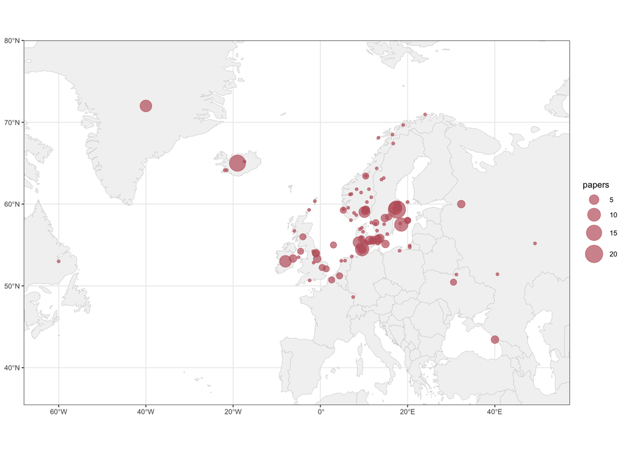

Named places mentioned in the corpus, sized by number of papers. Macro-region terms (Scandinavia, Viking world, and similar) are excluded even when Wikidata returns a coordinate for them, since a single point cannot honestly represent an area that broad — see the totals chart below for those. Cropped to the real spread of the remaining matched coordinates with a margin; a handful of correct but far-flung matches (e.g. Oceania, Pacific Ocean — real tokens in the corpus, real Wikidata matches) fall outside this crop and are not shown on the map.

**Table**

The map’s points. A token marked “no” is a real match that falls outside the plotting box and is not drawn.

| region | latitude | longitude | papers | on map |
| --- | --- | --- | --- | --- |
| Birka | 59.337 | 17.545 | 20 | yes |
| Iceland | 65.000 | -19.000 | 17 | yes |
| Gotland | 57.500 | 18.550 | 11 | yes |
| Hedeby | 54.491 | 9.565 | 11 | yes |
| Mälaren | 59.500 | 17.200 | 10 | yes |
| Greenland | 72.000 | -40.000 | 8 | yes |
| Ireland | 53.000 | -8.000 | 8 | yes |
| Kaupang | 59.031 | 10.108 | 7 | yes |
| Ribe | 55.327 | 8.763 | 7 | yes |
| Schleswig | 54.515 | 9.570 | 5 | yes |
| Scania | 55.800 | 13.617 | 4 | yes |
| Tissø | 55.576 | 11.292 | 4 | yes |
| Uppåkra | 55.667 | 13.171 | 4 | yes |
| Bornholm | 55.125 | 14.917 | 3 | yes |
| Danelaw | 54.000 | -1.000 | 3 | yes |
| Dublin | 53.350 | -6.260 | 3 | yes |
| Gokstad | 59.141 | 10.253 | 3 | yes |
| Lejre | 55.604 | 11.975 | 3 | yes |
| Oseberg | 59.310 | 10.453 | 3 | yes |
| Rök | 58.294 | 14.786 | 3 | yes |
| Salme | 43.432 | 40.027 | 3 | yes |
| Sigtuna | 59.617 | 17.724 | 3 | yes |
| Staraya Ladoga | 59.999 | 32.296 | 3 | yes |
| Torksey | 53.299 | -0.745 | 3 | yes |
| Antwerp | 51.221 | 4.400 | 2 | yes |
| Baltic | 58.000 | 20.000 | 2 | yes |
| Baltic Sea | 58.000 | 20.000 | 2 | yes |
| Borgring | 55.470 | 12.122 | 2 | yes |
| Borre | 50.731 | 2.584 | 2 | yes |
| Danevirke | 54.478 | 9.487 | 2 | yes |

[output cut: 87 more lines]

**Plot**

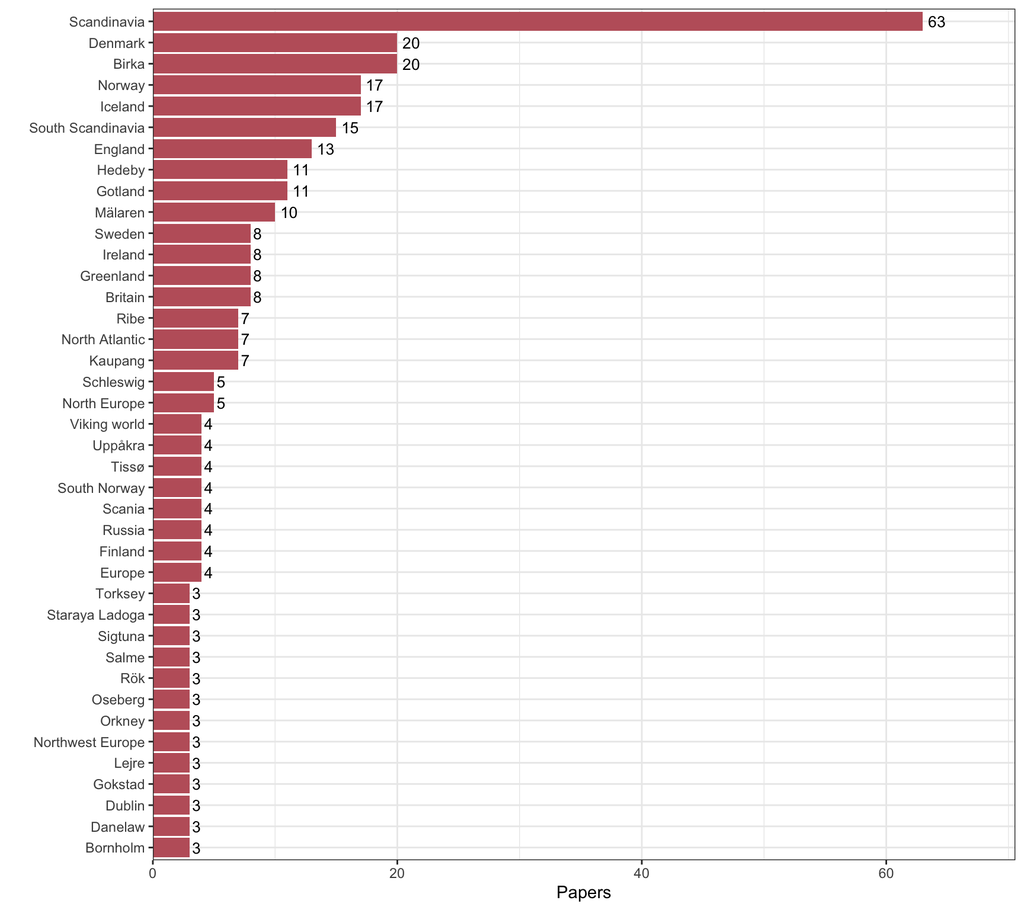

Every region token with at least 3 tagged papers, point-matched places and macro-region terms together, ranked by raw count.

**Table**

The plot’s numbers.

| region | papers |
| --- | --- |
| Scandinavia | 63 |
| Birka | 20 |
| Denmark | 20 |
| Iceland | 17 |
| Norway | 17 |
| South Scandinavia | 15 |
| England | 13 |
| Gotland | 11 |
| Hedeby | 11 |
| Mälaren | 10 |
| Britain | 8 |
| Greenland | 8 |
| Ireland | 8 |
| Sweden | 8 |
| Kaupang | 7 |
| North Atlantic | 7 |
| Ribe | 7 |
| North Europe | 5 |
| Schleswig | 5 |
| Europe | 4 |
| Finland | 4 |
| Russia | 4 |
| Scania | 4 |
| South Norway | 4 |
| Tissø | 4 |
| Uppåkra | 4 |
| Viking world | 4 |
| Bornholm | 3 |
| Danelaw | 3 |
| Dublin | 3 |
| Gokstad | 3 |
| Lejre | 3 |
| Northwest Europe | 3 |
| Orkney | 3 |
| Oseberg | 3 |
| Rök | 3 |
| Salme | 3 |
| Sigtuna | 3 |
| Staraya Ladoga | 3 |
| Torksey | 3 |

**By country (needs the nesting stage).** The chart above keeps every region token flat, “Birka” and “Sweden” and “Scandinavia” are three separate bars even though Birka is in Sweden — deliberately, since the paper’s own choice of a site-level or country-level term is itself part of what the data says, not noise to collapse away. This alternate view rolls site-level tags up to the country they’re actually in, using the `country` column that the nesting stage of `analysis/region_matching/` adds to the lookup (empty until that stage has been run). A paper tagged “Birka” counts toward Sweden here even if it was never separately tagged “Sweden.” Area names (Scandinavia, Viking world) have no single country and are excluded from this view. Country names (Sweden, Norway) count toward their own country, so a paper tagged only “Sweden” is included.

**Plot**

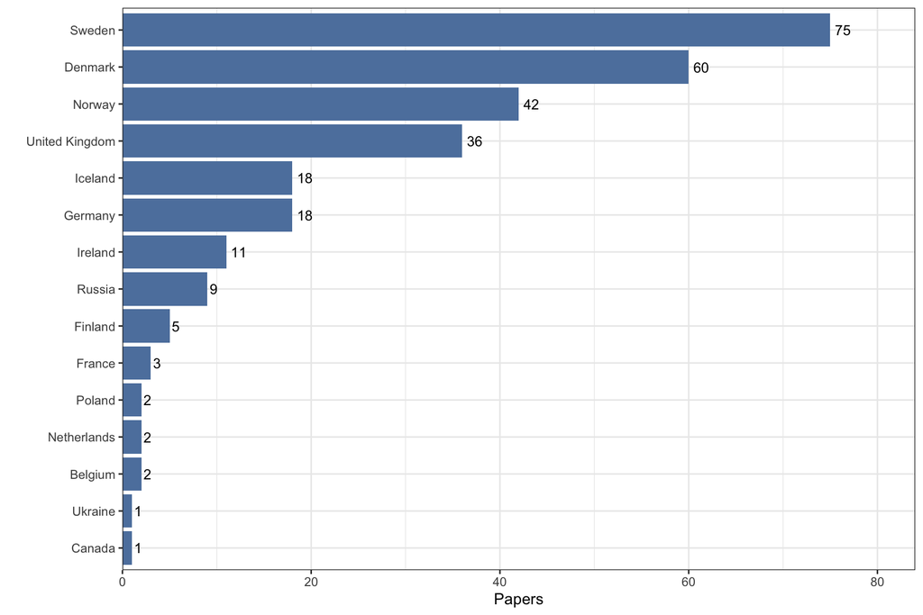

Papers per country, site-level tags rolled up to their containing country.

**Table**

The plot’s numbers.

| country | papers |
| --- | --- |
| Sweden | 75 |
| Denmark | 60 |
| Norway | 42 |
| United Kingdom | 36 |
| Germany | 18 |
| Iceland | 18 |
| Ireland | 11 |
| Russia | 9 |
| Finland | 5 |
| France | 3 |
| Belgium | 2 |
| Netherlands | 2 |
| Poland | 2 |
| Canada | 1 |
| Ukraine | 1 |

**Language by country.** The same countries, split by the language of the paper itself. Each bar stacks the F1 papers tagged with that country by language, using the language groups of “Language by year” in Part 0.

**Plot**

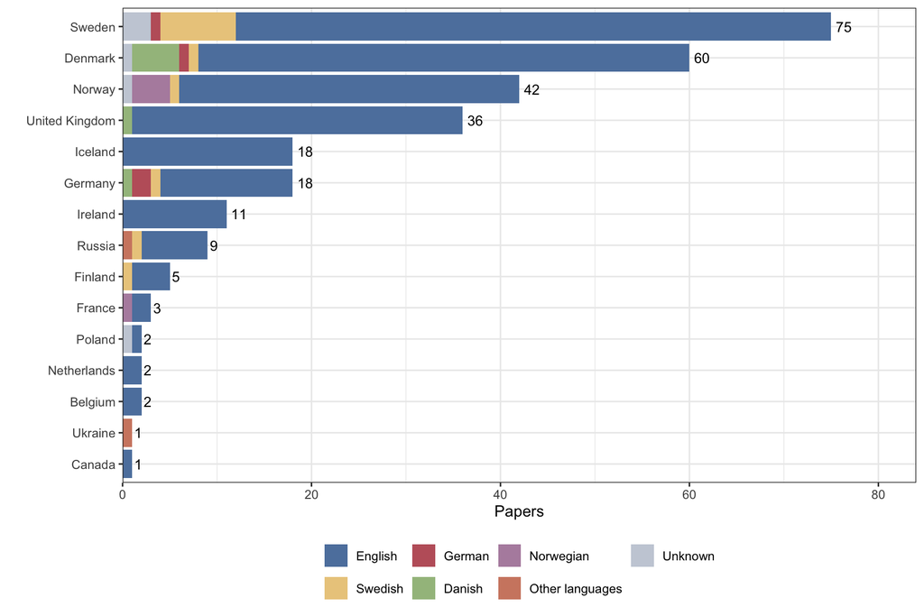

Papers per country, by language of the paper.

**Table**

The plot’s numbers.

| Country | English | Swedish | German | Danish | Norwegian | Other languages | Unknown | Papers |
| --- | --- | --- | --- | --- | --- | --- | --- | --- |
| Sweden | 63 | 8 | 1 | 0 | 0 | 0 | 3 | 75 |
| Denmark | 52 | 1 | 1 | 5 | 0 | 0 | 1 | 60 |
| Norway | 36 | 1 | 0 | 0 | 4 | 0 | 1 | 42 |
| United Kingdom | 35 | 0 | 0 | 1 | 0 | 0 | 0 | 36 |
| Germany | 14 | 1 | 2 | 1 | 0 | 0 | 0 | 18 |
| Iceland | 18 | 0 | 0 | 0 | 0 | 0 | 0 | 18 |
| Ireland | 11 | 0 | 0 | 0 | 0 | 0 | 0 | 11 |
| Russia | 7 | 1 | 0 | 0 | 0 | 1 | 0 | 9 |
| Finland | 4 | 1 | 0 | 0 | 0 | 0 | 0 | 5 |
| France | 2 | 0 | 0 | 0 | 1 | 0 | 0 | 3 |
| Belgium | 2 | 0 | 0 | 0 | 0 | 0 | 0 | 2 |
| Netherlands | 2 | 0 | 0 | 0 | 0 | 0 | 0 | 2 |
| Poland | 1 | 0 | 0 | 0 | 0 | 0 | 1 | 2 |
| Canada | 1 | 0 | 0 | 0 | 0 | 0 | 0 | 1 |
| Ukraine | 0 | 0 | 0 | 0 | 0 | 1 | 0 | 1 |

English is 87% of the 285 pairs of paper and country, and 9 of the 15 countries have at least one paper in a language other than English. The pairs come from 236 of the 369 F1 papers; the other 133 have no Region, or none that resolves to a country. A paper tagged with several countries appears once under each. The language is the paper’s own, taken from the body text of its PDF (see the Language section in Part 0); the 14 papers without a PDF use their title.

### Topic, method, and source by region

Same problem as gender composition above: most region tokens have too few papers to support a per-region proportion chart. Enrichment solves this differently — restricted to regions with at least 5 tagged papers, each cell shows that region’s coverage of a topic/method/source divided by that category’s own rate across the whole corpus (1.0x = corpus average), the same measure already used for cluster structure in Part 3. A region’s low paper count still means less certainty behind its cells, but enrichment at least says something real about *direction* even on a modest sample, where a stacked-proportion chart on the same sample would mostly just show noise. All three heatmaps below share the same region row order, so a region’s profile can be compared directly across tabs.

**Topic**

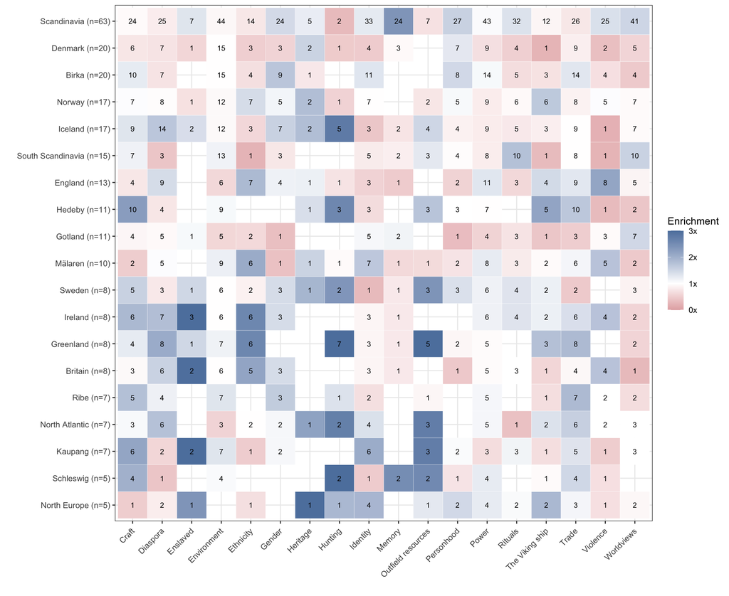

Topic enrichment by region (regions with 5+ tagged papers only). White = topic at corpus average rate for that region; blue = above average; red = below. Cell shows raw count behind the percentage. Capped at 3x so a handful of extreme small-n ratios don’t wash out the rest of the scale.

**Method**

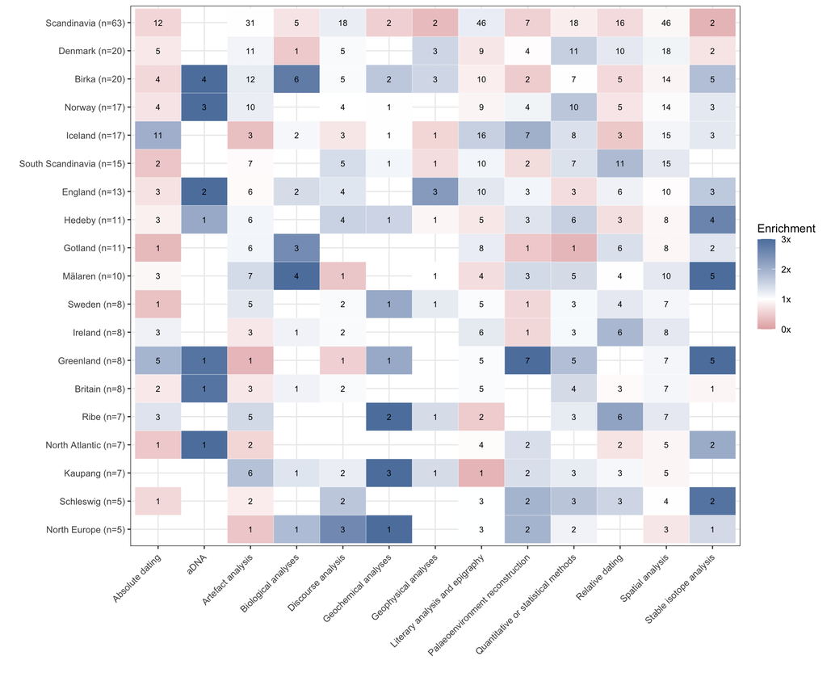

Method enrichment by region (regions with 5+ tagged papers only). Same reading as the topic heatmap above.

**Source of evidence**

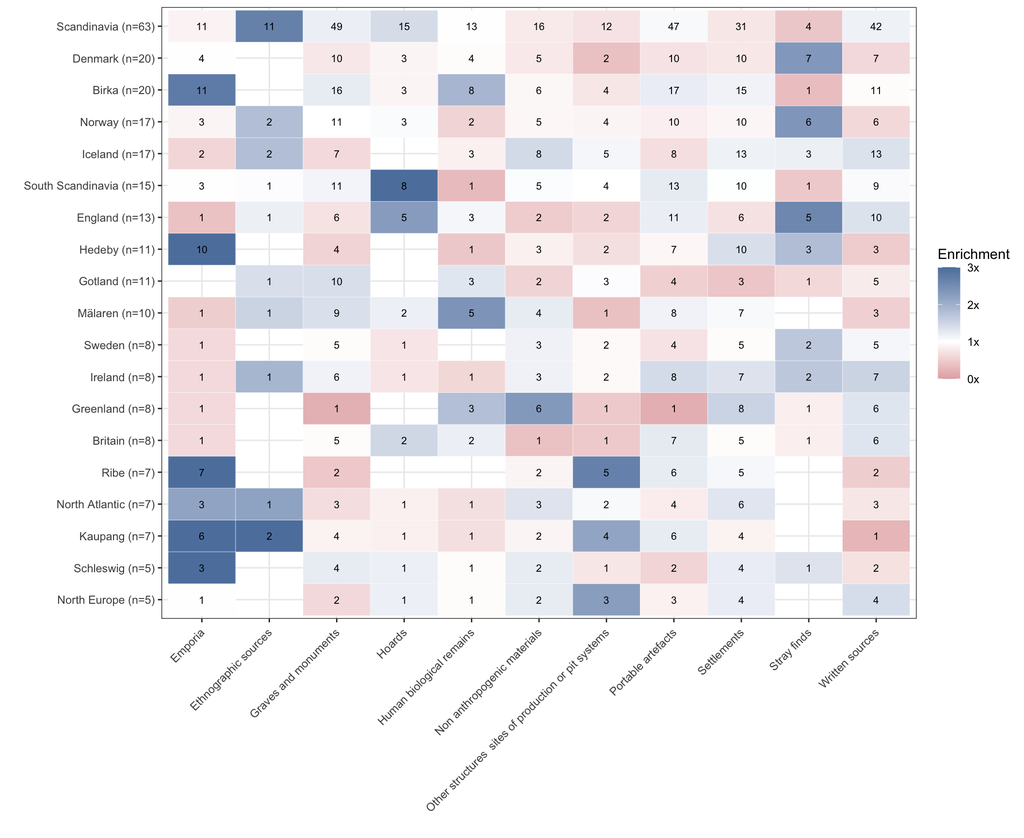

Source-of-evidence enrichment by region (regions with 5+ tagged papers only). Same reading as the topic heatmap above.

**Table, topic**

The topic heatmap’s numbers: one row per region and topic, from the region with the most papers down and, within a region, from the most enriched topic. Enrichment is the share of the region’s papers carrying the topic divided by the topic’s rate across the whole corpus (the baseline). The heatmap’s colour stops at 3x, the table does not.

| region | topic | papers | papers in row | share (%) | baseline rate (%) | enrichment |
| --- | --- | --- | --- | --- | --- | --- |
| Scandinavia (n=63) | Memory | 24 | 63 | 38.1 | 16.0 | 2.38 |
| Scandinavia (n=63) | Personhood | 27 | 63 | 42.9 | 27.4 | 1.57 |
| Scandinavia (n=63) | Worldviews | 41 | 63 | 65.1 | 43.1 | 1.51 |
| Scandinavia (n=63) | Gender | 24 | 63 | 38.1 | 26.3 | 1.45 |
| Scandinavia (n=63) | Violence | 25 | 63 | 39.7 | 28.7 | 1.38 |
| Scandinavia (n=63) | Rituals | 32 | 63 | 50.8 | 37.7 | 1.35 |
| Scandinavia (n=63) | Enslaved | 7 | 63 | 11.1 | 8.4 | 1.32 |
| Scandinavia (n=63) | Identity | 33 | 63 | 52.4 | 41.7 | 1.26 |
| Scandinavia (n=63) | Heritage | 5 | 63 | 7.9 | 6.5 | 1.22 |
| Scandinavia (n=63) | Power | 43 | 63 | 68.3 | 64.8 | 1.05 |
| Scandinavia (n=63) | Craft | 24 | 63 | 38.1 | 40.1 | 0.95 |
| Scandinavia (n=63) | Environment | 44 | 63 | 69.8 | 75.6 | 0.92 |
| Scandinavia (n=63) | The Viking ship | 12 | 63 | 19.0 | 21.1 | 0.90 |
| Scandinavia (n=63) | Diaspora | 25 | 63 | 39.7 | 48.5 | 0.82 |
| Scandinavia (n=63) | Ethnicity | 14 | 63 | 22.2 | 29.0 | 0.77 |
| Scandinavia (n=63) | Trade | 26 | 63 | 41.3 | 53.9 | 0.77 |
| Scandinavia (n=63) | Outfield resources | 7 | 63 | 11.1 | 15.7 | 0.71 |
| Scandinavia (n=63) | Hunting | 2 | 63 | 3.2 | 10.6 | 0.30 |
| Denmark (n=20) | Heritage | 2 | 20 | 10.0 | 6.5 | 1.54 |
| Denmark (n=20) | Personhood | 7 | 20 | 35.0 | 27.4 | 1.28 |
| Denmark (n=20) | Environment | 15 | 20 | 75.0 | 75.6 | 0.99 |
| Denmark (n=20) | Memory | 3 | 20 | 15.0 | 16.0 | 0.94 |
| Denmark (n=20) | Trade | 9 | 20 | 45.0 | 53.9 | 0.83 |
| Denmark (n=20) | Craft | 6 | 20 | 30.0 | 40.1 | 0.75 |
| Denmark (n=20) | Diaspora | 7 | 20 | 35.0 | 48.5 | 0.72 |
| Denmark (n=20) | Power | 9 | 20 | 45.0 | 64.8 | 0.69 |
| Denmark (n=20) | Enslaved | 1 | 20 | 5.0 | 8.4 | 0.60 |
| Denmark (n=20) | Worldviews | 5 | 20 | 25.0 | 43.1 | 0.58 |
| Denmark (n=20) | Gender | 3 | 20 | 15.0 | 26.3 | 0.57 |
| Denmark (n=20) | Rituals | 4 | 20 | 20.0 | 37.7 | 0.53 |

[output cut: 259 more lines]

**Table, method**

The method heatmap’s numbers, read as in Table, topic.

| region | method | papers | papers in row | share (%) | baseline rate (%) | enrichment |
| --- | --- | --- | --- | --- | --- | --- |
| Scandinavia (n=63) | Literary analysis and epigraphy | 46 | 63 | 73.0 | 59.6 | 1.22 |
| Scandinavia (n=63) | Discourse analysis | 18 | 63 | 28.6 | 23.6 | 1.21 |
| Scandinavia (n=63) | Artefact analysis | 31 | 63 | 49.2 | 48.8 | 1.01 |
| Scandinavia (n=63) | Spatial analysis | 46 | 63 | 73.0 | 79.1 | 0.92 |
| Scandinavia (n=63) | Quantitative or statistical methods | 18 | 63 | 28.6 | 34.7 | 0.82 |
| Scandinavia (n=63) | Biological analyses | 5 | 63 | 7.9 | 10.8 | 0.73 |
| Scandinavia (n=63) | Relative dating | 16 | 63 | 25.4 | 39.6 | 0.64 |
| Scandinavia (n=63) | Absolute dating | 12 | 63 | 19.0 | 32.2 | 0.59 |
| Scandinavia (n=63) | Palaeoenvironment reconstruction | 7 | 63 | 11.1 | 20.6 | 0.54 |
| Scandinavia (n=63) | Geochemical analyses | 2 | 63 | 3.2 | 6.0 | 0.53 |
| Scandinavia (n=63) | Geophysical analyses | 2 | 63 | 3.2 | 10.0 | 0.32 |
| Scandinavia (n=63) | Stable isotope analysis | 2 | 63 | 3.2 | 13.8 | 0.23 |
| Denmark (n=20) | Quantitative or statistical methods | 11 | 20 | 55.0 | 34.7 | 1.59 |
| Denmark (n=20) | Geophysical analyses | 3 | 20 | 15.0 | 10.0 | 1.50 |
| Denmark (n=20) | Relative dating | 10 | 20 | 50.0 | 39.6 | 1.26 |
| Denmark (n=20) | Spatial analysis | 18 | 20 | 90.0 | 79.1 | 1.14 |
| Denmark (n=20) | Artefact analysis | 11 | 20 | 55.0 | 48.8 | 1.13 |
| Denmark (n=20) | Discourse analysis | 5 | 20 | 25.0 | 23.6 | 1.06 |
| Denmark (n=20) | Palaeoenvironment reconstruction | 4 | 20 | 20.0 | 20.6 | 0.97 |
| Denmark (n=20) | Absolute dating | 5 | 20 | 25.0 | 32.2 | 0.78 |
| Denmark (n=20) | Literary analysis and epigraphy | 9 | 20 | 45.0 | 59.6 | 0.75 |
| Denmark (n=20) | Stable isotope analysis | 2 | 20 | 10.0 | 13.8 | 0.72 |
| Denmark (n=20) | Biological analyses | 1 | 20 | 5.0 | 10.8 | 0.46 |
| Birka (n=20) | aDNA | 4 | 20 | 20.0 | 4.3 | 4.61 |
| Birka (n=20) | Biological analyses | 6 | 20 | 30.0 | 10.8 | 2.77 |
| Birka (n=20) | Stable isotope analysis | 5 | 20 | 25.0 | 13.8 | 1.81 |
| Birka (n=20) | Geochemical analyses | 2 | 20 | 10.0 | 6.0 | 1.68 |
| Birka (n=20) | Geophysical analyses | 3 | 20 | 15.0 | 10.0 | 1.50 |
| Birka (n=20) | Artefact analysis | 12 | 20 | 60.0 | 48.8 | 1.23 |
| Birka (n=20) | Discourse analysis | 5 | 20 | 25.0 | 23.6 | 1.06 |

[output cut: 166 more lines]

**Table, source of evidence**

The source-of-evidence heatmap’s numbers, read as in Table, topic.

| region | source | papers | papers in row | share (%) | baseline rate (%) | enrichment |
| --- | --- | --- | --- | --- | --- | --- |
| Scandinavia (n=63) | Ethnographic sources | 11 | 63 | 17.5 | 6.5 | 2.68 |
| Scandinavia (n=63) | Hoards | 15 | 63 | 23.8 | 16.8 | 1.42 |
| Scandinavia (n=63) | Graves and monuments | 49 | 63 | 77.8 | 65.0 | 1.20 |
| Scandinavia (n=63) | Written sources | 42 | 63 | 66.7 | 56.9 | 1.17 |
| Scandinavia (n=63) | Portable artefacts | 47 | 63 | 74.6 | 69.6 | 1.07 |
| Scandinavia (n=63) | Human biological remains | 13 | 63 | 20.6 | 20.9 | 0.99 |
| Scandinavia (n=63) | Emporia | 11 | 63 | 17.5 | 19.8 | 0.88 |
| Scandinavia (n=63) | Non anthropogenic materials | 16 | 63 | 25.4 | 32.2 | 0.79 |
| Scandinavia (n=63) | Settlements | 31 | 63 | 49.2 | 65.3 | 0.75 |
| Scandinavia (n=63) | Other structures sites of production or pit systems | 12 | 63 | 19.0 | 26.6 | 0.72 |
| Scandinavia (n=63) | Stray finds | 4 | 63 | 6.3 | 14.9 | 0.43 |
| Denmark (n=20) | Stray finds | 7 | 20 | 35.0 | 14.9 | 2.35 |
| Denmark (n=20) | Emporia | 4 | 20 | 20.0 | 19.8 | 1.01 |
| Denmark (n=20) | Human biological remains | 4 | 20 | 20.0 | 20.9 | 0.96 |
| Denmark (n=20) | Hoards | 3 | 20 | 15.0 | 16.8 | 0.89 |
| Denmark (n=20) | Non anthropogenic materials | 5 | 20 | 25.0 | 32.2 | 0.78 |
| Denmark (n=20) | Graves and monuments | 10 | 20 | 50.0 | 65.0 | 0.77 |
| Denmark (n=20) | Settlements | 10 | 20 | 50.0 | 65.3 | 0.77 |
| Denmark (n=20) | Portable artefacts | 10 | 20 | 50.0 | 69.6 | 0.72 |
| Denmark (n=20) | Written sources | 7 | 20 | 35.0 | 56.9 | 0.62 |
| Denmark (n=20) | Other structures sites of production or pit systems | 2 | 20 | 10.0 | 26.6 | 0.38 |
| Birka (n=20) | Emporia | 11 | 20 | 55.0 | 19.8 | 2.78 |
| Birka (n=20) | Human biological remains | 8 | 20 | 40.0 | 20.9 | 1.92 |
| Birka (n=20) | Graves and monuments | 16 | 20 | 80.0 | 65.0 | 1.23 |
| Birka (n=20) | Portable artefacts | 17 | 20 | 85.0 | 69.6 | 1.22 |
| Birka (n=20) | Settlements | 15 | 20 | 75.0 | 65.3 | 1.15 |
| Birka (n=20) | Written sources | 11 | 20 | 55.0 | 56.9 | 0.97 |
| Birka (n=20) | Non anthropogenic materials | 6 | 20 | 30.0 | 32.2 | 0.93 |
| Birka (n=20) | Hoards | 3 | 20 | 15.0 | 16.8 | 0.89 |
| Birka (n=20) | Other structures sites of production or pit systems | 4 | 20 | 20.0 | 26.6 | 0.75 |

[output cut: 157 more lines]

### Topic, method, and source by country and super-region

The tabset above groups by the raw region token as written in each paper, “Birka” and “Sweden” stay separate rows even though one is inside the other. This section repeats the same topic/method/source enrichment analysis, but grouped at each of the two nesting levels resolved by the nesting stage of `analysis/region_matching/` instead: country and super-region. Requires that stage to have been run at least once — each tab below says what to do if its column is empty.

The enrichment baseline here is different from the tabset above, on purpose: each cell compares a group’s rate against the rate among only the papers that resolved to *some* value at that nesting level, not against the whole 369-paper F1 corpus. The flat-token tabset above uses the whole-corpus rate, since every F1 paper is a fair comparison point for a raw region tag. Nesting-level resolution is a narrower subset (only papers whose region successfully resolved up to a country, say), so comparing against the whole corpus would dilute the baseline with papers that never entered this analysis at all and understate real enrichment within the resolved set. Enrichment numbers are therefore not directly comparable between the two tabsets, even when they group the same underlying papers.

**By country**

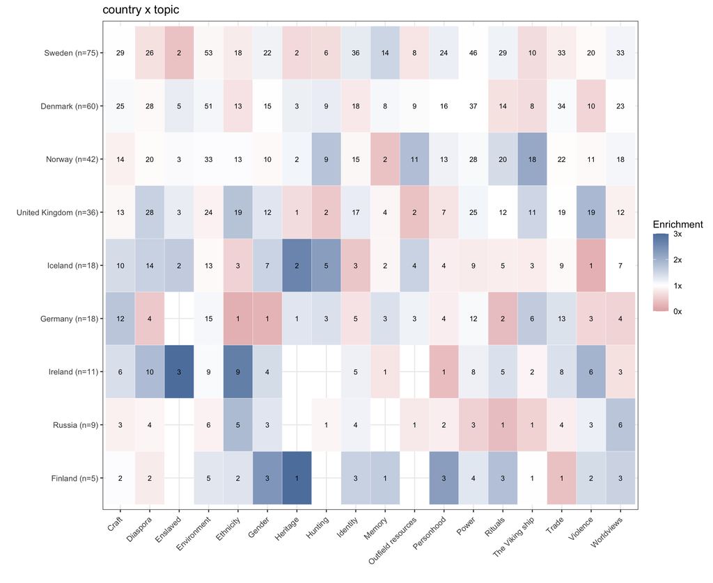

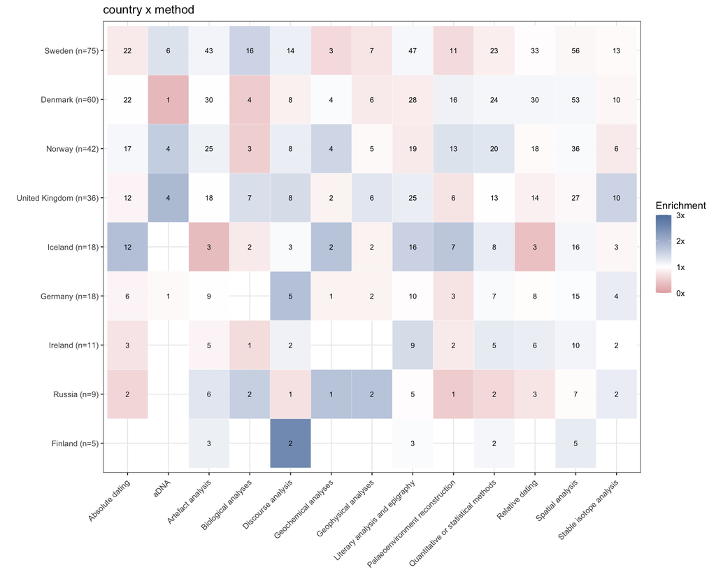

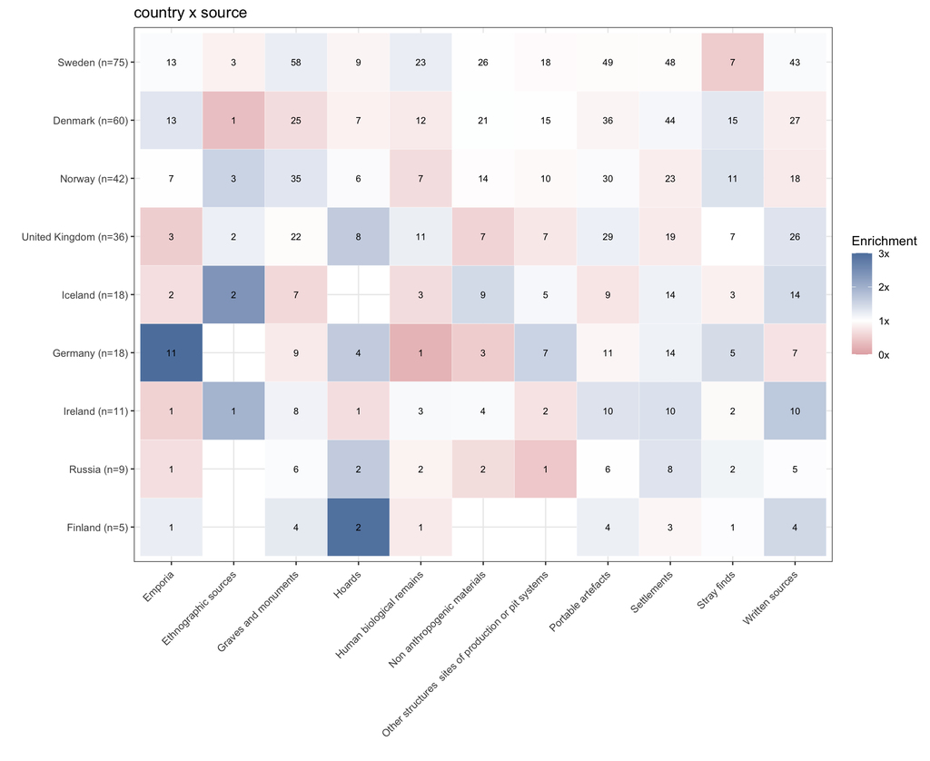

**By super-region**

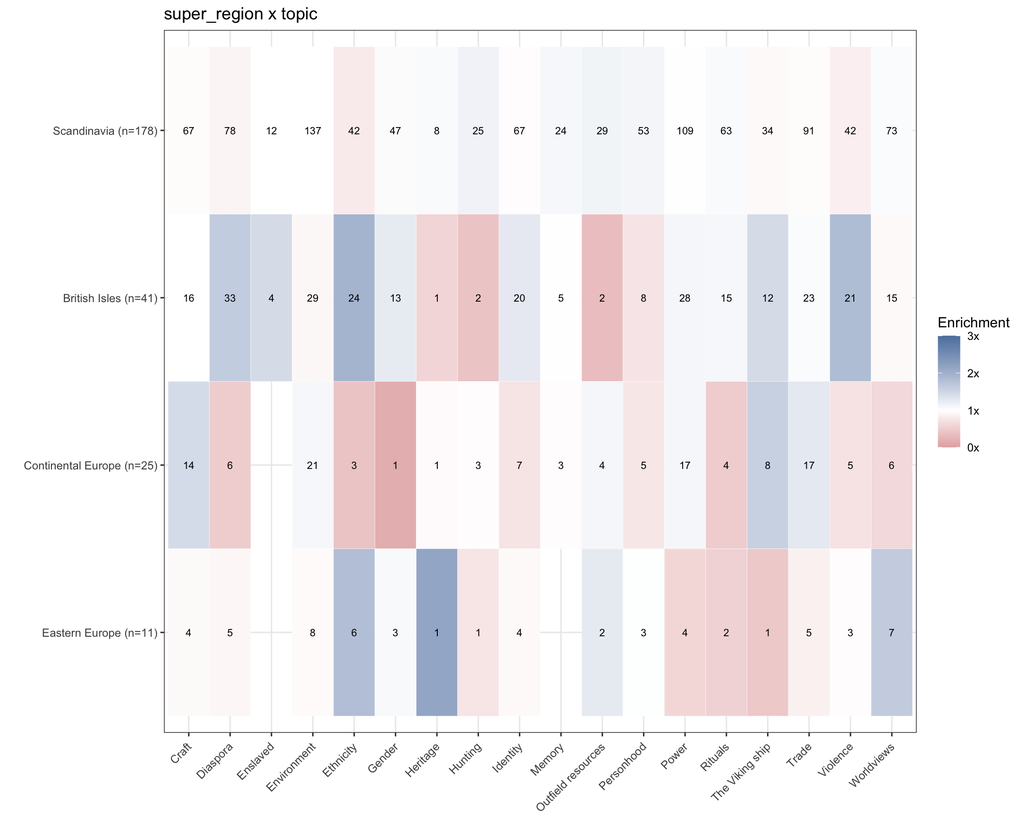

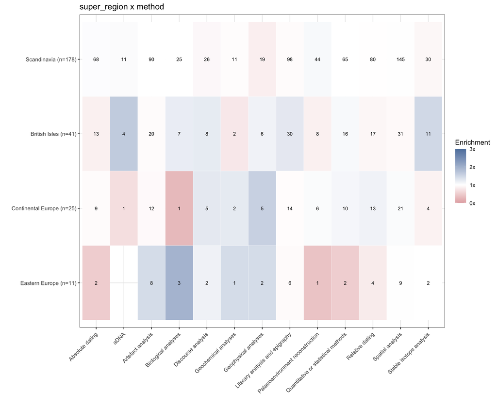

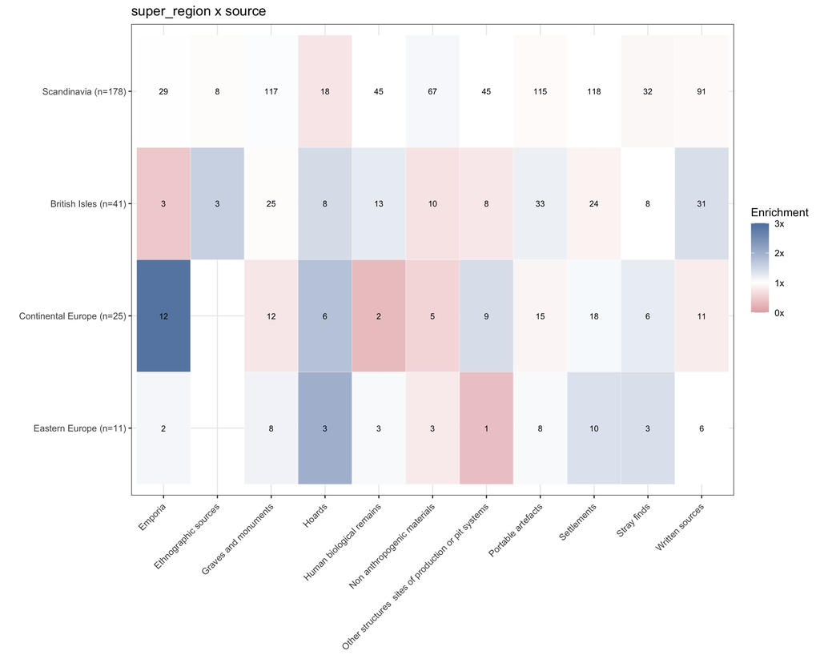

**Table, by country**

The by country heatmaps’ numbers, one table each for topic, method and source of evidence. The baseline is the category’s rate among the papers that have a value at this level, as described above.

Topic

| country | topic | papers | papers in row | share (%) | baseline rate (%) | enrichment |
| --- | --- | --- | --- | --- | --- | --- |
| Sweden (n=75) | Memory | 14 | 75 | 18.7 | 12.3 | 1.52 |
| Sweden (n=75) | Identity | 36 | 75 | 48.0 | 38.6 | 1.24 |
| Sweden (n=75) | Personhood | 24 | 75 | 32.0 | 26.7 | 1.20 |
| Sweden (n=75) | Rituals | 29 | 75 | 38.7 | 33.5 | 1.16 |
| Sweden (n=75) | Gender | 22 | 75 | 29.3 | 25.4 | 1.15 |
| Sweden (n=75) | Worldviews | 33 | 75 | 44.0 | 39.0 | 1.13 |
| Sweden (n=75) | Craft | 29 | 75 | 38.7 | 39.0 | 0.99 |
| Sweden (n=75) | Power | 46 | 75 | 61.3 | 61.9 | 0.99 |
| Sweden (n=75) | Violence | 20 | 75 | 26.7 | 28.0 | 0.95 |
| Sweden (n=75) | Environment | 53 | 75 | 70.7 | 76.7 | 0.92 |
| Sweden (n=75) | Trade | 33 | 75 | 44.0 | 53.4 | 0.82 |
| Sweden (n=75) | Ethnicity | 18 | 75 | 24.0 | 30.1 | 0.80 |
| Sweden (n=75) | Outfield resources | 8 | 75 | 10.7 | 14.4 | 0.74 |
| Sweden (n=75) | Diaspora | 26 | 75 | 34.7 | 49.6 | 0.70 |
| Sweden (n=75) | The Viking ship | 10 | 75 | 13.3 | 20.3 | 0.66 |
| Sweden (n=75) | Hunting | 6 | 75 | 8.0 | 12.3 | 0.65 |
| Sweden (n=75) | Heritage | 2 | 75 | 2.7 | 4.2 | 0.63 |
| Sweden (n=75) | Enslaved | 2 | 75 | 2.7 | 6.8 | 0.39 |
| Denmark (n=60) | Enslaved | 5 | 60 | 8.3 | 6.8 | 1.23 |
| Denmark (n=60) | Hunting | 9 | 60 | 15.0 | 12.3 | 1.22 |
| Denmark (n=60) | Heritage | 3 | 60 | 5.0 | 4.2 | 1.18 |
| Denmark (n=60) | Environment | 51 | 60 | 85.0 | 76.7 | 1.11 |
| Denmark (n=60) | Memory | 8 | 60 | 13.3 | 12.3 | 1.09 |
| Denmark (n=60) | Craft | 25 | 60 | 41.7 | 39.0 | 1.07 |
| Denmark (n=60) | Trade | 34 | 60 | 56.7 | 53.4 | 1.06 |
| Denmark (n=60) | Outfield resources | 9 | 60 | 15.0 | 14.4 | 1.04 |
| Denmark (n=60) | Personhood | 16 | 60 | 26.7 | 26.7 | 1.00 |
| Denmark (n=60) | Power | 37 | 60 | 61.7 | 61.9 | 1.00 |
| Denmark (n=60) | Gender | 15 | 60 | 25.0 | 25.4 | 0.98 |
| Denmark (n=60) | Worldviews | 23 | 60 | 38.3 | 39.0 | 0.98 |

[output cut: 122 more lines]

Method

| country | method | papers | papers in row | share (%) | baseline rate (%) | enrichment |
| --- | --- | --- | --- | --- | --- | --- |
| Sweden (n=75) | Biological analyses | 16 | 75 | 21.3 | 14.0 | 1.53 |
| Sweden (n=75) | aDNA | 6 | 75 | 8.0 | 5.9 | 1.35 |
| Sweden (n=75) | Discourse analysis | 14 | 75 | 18.7 | 15.7 | 1.19 |
| Sweden (n=75) | Artefact analysis | 43 | 75 | 57.3 | 50.8 | 1.13 |
| Sweden (n=75) | Literary analysis and epigraphy | 47 | 75 | 62.7 | 57.2 | 1.10 |
| Sweden (n=75) | Relative dating | 33 | 75 | 44.0 | 45.3 | 0.97 |
| Sweden (n=75) | Stable isotope analysis | 13 | 75 | 17.3 | 18.2 | 0.95 |
| Sweden (n=75) | Spatial analysis | 56 | 75 | 74.7 | 80.5 | 0.93 |
| Sweden (n=75) | Quantitative or statistical methods | 23 | 75 | 30.7 | 36.4 | 0.84 |
| Sweden (n=75) | Absolute dating | 22 | 75 | 29.3 | 37.3 | 0.79 |
| Sweden (n=75) | Geophysical analyses | 7 | 75 | 9.3 | 12.7 | 0.73 |
| Sweden (n=75) | Palaeoenvironment reconstruction | 11 | 75 | 14.7 | 22.9 | 0.64 |
| Sweden (n=75) | Geochemical analyses | 3 | 75 | 4.0 | 6.4 | 0.63 |
| Denmark (n=60) | Palaeoenvironment reconstruction | 16 | 60 | 26.7 | 22.9 | 1.17 |
| Denmark (n=60) | Relative dating | 30 | 60 | 50.0 | 45.3 | 1.10 |
| Denmark (n=60) | Quantitative or statistical methods | 24 | 60 | 40.0 | 36.4 | 1.10 |
| Denmark (n=60) | Spatial analysis | 53 | 60 | 88.3 | 80.5 | 1.10 |
| Denmark (n=60) | Geochemical analyses | 4 | 60 | 6.7 | 6.4 | 1.05 |
| Denmark (n=60) | Artefact analysis | 30 | 60 | 50.0 | 50.8 | 0.98 |
| Denmark (n=60) | Absolute dating | 22 | 60 | 36.7 | 37.3 | 0.98 |
| Denmark (n=60) | Stable isotope analysis | 10 | 60 | 16.7 | 18.2 | 0.91 |
| Denmark (n=60) | Discourse analysis | 8 | 60 | 13.3 | 15.7 | 0.85 |
| Denmark (n=60) | Literary analysis and epigraphy | 28 | 60 | 46.7 | 57.2 | 0.82 |
| Denmark (n=60) | Geophysical analyses | 6 | 60 | 10.0 | 12.7 | 0.79 |
| Denmark (n=60) | Biological analyses | 4 | 60 | 6.7 | 14.0 | 0.48 |
| Denmark (n=60) | aDNA | 1 | 60 | 1.7 | 5.9 | 0.28 |
| Norway (n=42) | aDNA | 4 | 42 | 9.5 | 5.9 | 1.61 |
| Norway (n=42) | Geochemical analyses | 4 | 42 | 9.5 | 6.4 | 1.50 |
| Norway (n=42) | Palaeoenvironment reconstruction | 13 | 42 | 31.0 | 22.9 | 1.35 |
| Norway (n=42) | Quantitative or statistical methods | 20 | 42 | 47.6 | 36.4 | 1.31 |

[output cut: 73 more lines]

Source of evidence

| country | source | papers | papers in row | share (%) | baseline rate (%) | enrichment |
| --- | --- | --- | --- | --- | --- | --- |
| Sweden (n=75) | Graves and monuments | 58 | 75 | 77.3 | 63.6 | 1.22 |
| Sweden (n=75) | Human biological remains | 23 | 75 | 30.7 | 25.4 | 1.21 |
| Sweden (n=75) | Written sources | 43 | 75 | 57.3 | 54.2 | 1.06 |
| Sweden (n=75) | Emporia | 13 | 75 | 17.3 | 16.5 | 1.05 |
| Sweden (n=75) | Non anthropogenic materials | 26 | 75 | 34.7 | 34.3 | 1.01 |
| Sweden (n=75) | Portable artefacts | 49 | 75 | 65.3 | 67.8 | 0.96 |
| Sweden (n=75) | Settlements | 48 | 75 | 64.0 | 66.5 | 0.96 |
| Sweden (n=75) | Other structures sites of production or pit systems | 18 | 75 | 24.0 | 25.4 | 0.94 |
| Sweden (n=75) | Hoards | 9 | 75 | 12.0 | 13.6 | 0.88 |
| Sweden (n=75) | Ethnographic sources | 3 | 75 | 4.0 | 4.7 | 0.86 |
| Sweden (n=75) | Stray finds | 7 | 75 | 9.3 | 19.5 | 0.48 |
| Denmark (n=60) | Emporia | 13 | 60 | 21.7 | 16.5 | 1.31 |
| Denmark (n=60) | Stray finds | 15 | 60 | 25.0 | 19.5 | 1.28 |
| Denmark (n=60) | Settlements | 44 | 60 | 73.3 | 66.5 | 1.10 |
| Denmark (n=60) | Non anthropogenic materials | 21 | 60 | 35.0 | 34.3 | 1.02 |
| Denmark (n=60) | Other structures sites of production or pit systems | 15 | 60 | 25.0 | 25.4 | 0.98 |
| Denmark (n=60) | Portable artefacts | 36 | 60 | 60.0 | 67.8 | 0.88 |
| Denmark (n=60) | Hoards | 7 | 60 | 11.7 | 13.6 | 0.86 |
| Denmark (n=60) | Written sources | 27 | 60 | 45.0 | 54.2 | 0.83 |
| Denmark (n=60) | Human biological remains | 12 | 60 | 20.0 | 25.4 | 0.79 |
| Denmark (n=60) | Graves and monuments | 25 | 60 | 41.7 | 63.6 | 0.66 |
| Denmark (n=60) | Ethnographic sources | 1 | 60 | 1.7 | 4.7 | 0.36 |
| Norway (n=42) | Ethnographic sources | 3 | 42 | 7.1 | 4.7 | 1.53 |
| Norway (n=42) | Stray finds | 11 | 42 | 26.2 | 19.5 | 1.34 |
| Norway (n=42) | Graves and monuments | 35 | 42 | 83.3 | 63.6 | 1.31 |
| Norway (n=42) | Hoards | 6 | 42 | 14.3 | 13.6 | 1.05 |
| Norway (n=42) | Portable artefacts | 30 | 42 | 71.4 | 67.8 | 1.05 |
| Norway (n=42) | Emporia | 7 | 42 | 16.7 | 16.5 | 1.01 |
| Norway (n=42) | Non anthropogenic materials | 14 | 42 | 33.3 | 34.3 | 0.97 |
| Norway (n=42) | Other structures sites of production or pit systems | 10 | 42 | 23.8 | 25.4 | 0.94 |

[output cut: 63 more lines]

**Table, by super-region**

The by super-region heatmaps’ numbers, one table each for topic, method and source of evidence. The baseline is the category’s rate among the papers that have a value at this level, as described above.

Topic

| super-region | topic | papers | papers in row | share (%) | baseline rate (%) | enrichment |
| --- | --- | --- | --- | --- | --- | --- |
| Scandinavia (n=178) | Hunting | 25 | 178 | 14.0 | 12.3 | 1.14 |
| Scandinavia (n=178) | Outfield resources | 29 | 178 | 16.3 | 14.4 | 1.13 |
| Scandinavia (n=178) | Personhood | 53 | 178 | 29.8 | 26.7 | 1.12 |
| Scandinavia (n=178) | Memory | 24 | 178 | 13.5 | 12.3 | 1.10 |
| Scandinavia (n=178) | Heritage | 8 | 178 | 4.5 | 4.2 | 1.06 |
| Scandinavia (n=178) | Rituals | 63 | 178 | 35.4 | 33.5 | 1.06 |
| Scandinavia (n=178) | Worldviews | 73 | 178 | 41.0 | 39.0 | 1.05 |
| Scandinavia (n=178) | Gender | 47 | 178 | 26.4 | 25.4 | 1.04 |
| Scandinavia (n=178) | Environment | 137 | 178 | 77.0 | 76.7 | 1.00 |
| Scandinavia (n=178) | Enslaved | 12 | 178 | 6.7 | 6.8 | 0.99 |
| Scandinavia (n=178) | Power | 109 | 178 | 61.2 | 61.9 | 0.99 |
| Scandinavia (n=178) | Identity | 67 | 178 | 37.6 | 38.6 | 0.98 |
| Scandinavia (n=178) | Craft | 67 | 178 | 37.6 | 39.0 | 0.97 |
| Scandinavia (n=178) | Trade | 91 | 178 | 51.1 | 53.4 | 0.96 |
| Scandinavia (n=178) | The Viking ship | 34 | 178 | 19.1 | 20.3 | 0.94 |
| Scandinavia (n=178) | Diaspora | 78 | 178 | 43.8 | 49.6 | 0.88 |
| Scandinavia (n=178) | Violence | 42 | 178 | 23.6 | 28.0 | 0.84 |
| Scandinavia (n=178) | Ethnicity | 42 | 178 | 23.6 | 30.1 | 0.78 |
| British Isles (n=41) | Ethnicity | 24 | 41 | 58.5 | 30.1 | 1.95 |
| British Isles (n=41) | Violence | 21 | 41 | 51.2 | 28.0 | 1.83 |
| British Isles (n=41) | Diaspora | 33 | 41 | 80.5 | 49.6 | 1.62 |
| British Isles (n=41) | Enslaved | 4 | 41 | 9.8 | 6.8 | 1.44 |
| British Isles (n=41) | The Viking ship | 12 | 41 | 29.3 | 20.3 | 1.44 |
| British Isles (n=41) | Identity | 20 | 41 | 48.8 | 38.6 | 1.27 |
| British Isles (n=41) | Gender | 13 | 41 | 31.7 | 25.4 | 1.25 |
| British Isles (n=41) | Power | 28 | 41 | 68.3 | 61.9 | 1.10 |
| British Isles (n=41) | Rituals | 15 | 41 | 36.6 | 33.5 | 1.09 |
| British Isles (n=41) | Trade | 23 | 41 | 56.1 | 53.4 | 1.05 |
| British Isles (n=41) | Craft | 16 | 41 | 39.0 | 39.0 | 1.00 |
| British Isles (n=41) | Memory | 5 | 41 | 12.2 | 12.3 | 0.99 |
| British Isles (n=41) | Worldviews | 15 | 41 | 36.6 | 39.0 | 0.94 |
| British Isles (n=41) | Environment | 29 | 41 | 70.7 | 76.7 | 0.92 |
| British Isles (n=41) | Personhood | 8 | 41 | 19.5 | 26.7 | 0.73 |
| British Isles (n=41) | Heritage | 1 | 41 | 2.4 | 4.2 | 0.58 |
| British Isles (n=41) | Hunting | 2 | 41 | 4.9 | 12.3 | 0.40 |
| British Isles (n=41) | Outfield resources | 2 | 41 | 4.9 | 14.4 | 0.34 |
| Continental Europe (n=25) | The Viking ship | 8 | 25 | 32.0 | 20.3 | 1.57 |
| Continental Europe (n=25) | Craft | 14 | 25 | 56.0 | 39.0 | 1.44 |
| Continental Europe (n=25) | Trade | 17 | 25 | 68.0 | 53.4 | 1.27 |
| Continental Europe (n=25) | Outfield resources | 4 | 25 | 16.0 | 14.4 | 1.11 |
| Continental Europe (n=25) | Power | 17 | 25 | 68.0 | 61.9 | 1.10 |
| Continental Europe (n=25) | Environment | 21 | 25 | 84.0 | 76.7 | 1.10 |
| Continental Europe (n=25) | Hunting | 3 | 25 | 12.0 | 12.3 | 0.98 |
| Continental Europe (n=25) | Memory | 3 | 25 | 12.0 | 12.3 | 0.98 |
| Continental Europe (n=25) | Heritage | 1 | 25 | 4.0 | 4.2 | 0.94 |
| Continental Europe (n=25) | Personhood | 5 | 25 | 20.0 | 26.7 | 0.75 |
| Continental Europe (n=25) | Identity | 7 | 25 | 28.0 | 38.6 | 0.73 |
| Continental Europe (n=25) | Violence | 5 | 25 | 20.0 | 28.0 | 0.72 |
| Continental Europe (n=25) | Worldviews | 6 | 25 | 24.0 | 39.0 | 0.62 |
| Continental Europe (n=25) | Diaspora | 6 | 25 | 24.0 | 49.6 | 0.48 |
| Continental Europe (n=25) | Rituals | 4 | 25 | 16.0 | 33.5 | 0.48 |
| Continental Europe (n=25) | Ethnicity | 3 | 25 | 12.0 | 30.1 | 0.40 |
| Continental Europe (n=25) | Gender | 1 | 25 | 4.0 | 25.4 | 0.16 |
| Eastern Europe (n=11) | Heritage | 1 | 11 | 9.1 | 4.2 | 2.15 |
| Eastern Europe (n=11) | Ethnicity | 6 | 11 | 54.5 | 30.1 | 1.81 |
| Eastern Europe (n=11) | Worldviews | 7 | 11 | 63.6 | 39.0 | 1.63 |
| Eastern Europe (n=11) | Outfield resources | 2 | 11 | 18.2 | 14.4 | 1.26 |
| Eastern Europe (n=11) | Gender | 3 | 11 | 27.3 | 25.4 | 1.07 |
| Eastern Europe (n=11) | Personhood | 3 | 11 | 27.3 | 26.7 | 1.02 |
| Eastern Europe (n=11) | Violence | 3 | 11 | 27.3 | 28.0 | 0.98 |
| Eastern Europe (n=11) | Environment | 8 | 11 | 72.7 | 76.7 | 0.95 |
| Eastern Europe (n=11) | Identity | 4 | 11 | 36.4 | 38.6 | 0.94 |
| Eastern Europe (n=11) | Craft | 4 | 11 | 36.4 | 39.0 | 0.93 |
| Eastern Europe (n=11) | Diaspora | 5 | 11 | 45.5 | 49.6 | 0.92 |
| Eastern Europe (n=11) | Trade | 5 | 11 | 45.5 | 53.4 | 0.85 |
| Eastern Europe (n=11) | Hunting | 1 | 11 | 9.1 | 12.3 | 0.74 |
| Eastern Europe (n=11) | Power | 4 | 11 | 36.4 | 61.9 | 0.59 |
| Eastern Europe (n=11) | Rituals | 2 | 11 | 18.2 | 33.5 | 0.54 |
| Eastern Europe (n=11) | The Viking ship | 1 | 11 | 9.1 | 20.3 | 0.45 |

Method

| super-region | method | papers | papers in row | share (%) | baseline rate (%) | enrichment |
| --- | --- | --- | --- | --- | --- | --- |
| Scandinavia (n=178) | Palaeoenvironment reconstruction | 44 | 178 | 24.7 | 22.9 | 1.08 |
| Scandinavia (n=178) | aDNA | 11 | 178 | 6.2 | 5.9 | 1.04 |
| Scandinavia (n=178) | Absolute dating | 68 | 178 | 38.2 | 37.3 | 1.02 |
| Scandinavia (n=178) | Spatial analysis | 145 | 178 | 81.5 | 80.5 | 1.01 |
| Scandinavia (n=178) | Biological analyses | 25 | 178 | 14.0 | 14.0 | 1.00 |
| Scandinavia (n=178) | Quantitative or statistical methods | 65 | 178 | 36.5 | 36.4 | 1.00 |
| Scandinavia (n=178) | Artefact analysis | 90 | 178 | 50.6 | 50.8 | 0.99 |
| Scandinavia (n=178) | Relative dating | 80 | 178 | 44.9 | 45.3 | 0.99 |
| Scandinavia (n=178) | Geochemical analyses | 11 | 178 | 6.2 | 6.4 | 0.97 |
| Scandinavia (n=178) | Literary analysis and epigraphy | 98 | 178 | 55.1 | 57.2 | 0.96 |
| Scandinavia (n=178) | Discourse analysis | 26 | 178 | 14.6 | 15.7 | 0.93 |
| Scandinavia (n=178) | Stable isotope analysis | 30 | 178 | 16.9 | 18.2 | 0.93 |
| Scandinavia (n=178) | Geophysical analyses | 19 | 178 | 10.7 | 12.7 | 0.84 |
| British Isles (n=41) | aDNA | 4 | 41 | 9.8 | 5.9 | 1.64 |
| British Isles (n=41) | Stable isotope analysis | 11 | 41 | 26.8 | 18.2 | 1.47 |
| British Isles (n=41) | Literary analysis and epigraphy | 30 | 41 | 73.2 | 57.2 | 1.28 |
| British Isles (n=41) | Discourse analysis | 8 | 41 | 19.5 | 15.7 | 1.24 |
| British Isles (n=41) | Biological analyses | 7 | 41 | 17.1 | 14.0 | 1.22 |
| British Isles (n=41) | Geophysical analyses | 6 | 41 | 14.6 | 12.7 | 1.15 |
| British Isles (n=41) | Quantitative or statistical methods | 16 | 41 | 39.0 | 36.4 | 1.07 |
| British Isles (n=41) | Artefact analysis | 20 | 41 | 48.8 | 50.8 | 0.96 |
| British Isles (n=41) | Spatial analysis | 31 | 41 | 75.6 | 80.5 | 0.94 |
| British Isles (n=41) | Relative dating | 17 | 41 | 41.5 | 45.3 | 0.91 |
| British Isles (n=41) | Palaeoenvironment reconstruction | 8 | 41 | 19.5 | 22.9 | 0.85 |
| British Isles (n=41) | Absolute dating | 13 | 41 | 31.7 | 37.3 | 0.85 |
| British Isles (n=41) | Geochemical analyses | 2 | 41 | 4.9 | 6.4 | 0.77 |
| Continental Europe (n=25) | Geophysical analyses | 5 | 25 | 20.0 | 12.7 | 1.57 |
| Continental Europe (n=25) | Discourse analysis | 5 | 25 | 20.0 | 15.7 | 1.28 |
| Continental Europe (n=25) | Geochemical analyses | 2 | 25 | 8.0 | 6.4 | 1.26 |
| Continental Europe (n=25) | Relative dating | 13 | 25 | 52.0 | 45.3 | 1.15 |
| Continental Europe (n=25) | Quantitative or statistical methods | 10 | 25 | 40.0 | 36.4 | 1.10 |
| Continental Europe (n=25) | Palaeoenvironment reconstruction | 6 | 25 | 24.0 | 22.9 | 1.05 |
| Continental Europe (n=25) | Spatial analysis | 21 | 25 | 84.0 | 80.5 | 1.04 |
| Continental Europe (n=25) | Literary analysis and epigraphy | 14 | 25 | 56.0 | 57.2 | 0.98 |
| Continental Europe (n=25) | Absolute dating | 9 | 25 | 36.0 | 37.3 | 0.97 |
| Continental Europe (n=25) | Artefact analysis | 12 | 25 | 48.0 | 50.8 | 0.94 |
| Continental Europe (n=25) | Stable isotope analysis | 4 | 25 | 16.0 | 18.2 | 0.88 |
| Continental Europe (n=25) | aDNA | 1 | 25 | 4.0 | 5.9 | 0.67 |
| Continental Europe (n=25) | Biological analyses | 1 | 25 | 4.0 | 14.0 | 0.29 |
| Eastern Europe (n=11) | Biological analyses | 3 | 11 | 27.3 | 14.0 | 1.95 |
| Eastern Europe (n=11) | Artefact analysis | 8 | 11 | 72.7 | 50.8 | 1.43 |
| Eastern Europe (n=11) | Geochemical analyses | 1 | 11 | 9.1 | 6.4 | 1.43 |
| Eastern Europe (n=11) | Geophysical analyses | 2 | 11 | 18.2 | 12.7 | 1.43 |
| Eastern Europe (n=11) | Discourse analysis | 2 | 11 | 18.2 | 15.7 | 1.16 |
| Eastern Europe (n=11) | Spatial analysis | 9 | 11 | 81.8 | 80.5 | 1.02 |
| Eastern Europe (n=11) | Stable isotope analysis | 2 | 11 | 18.2 | 18.2 | 1.00 |
| Eastern Europe (n=11) | Literary analysis and epigraphy | 6 | 11 | 54.5 | 57.2 | 0.95 |
| Eastern Europe (n=11) | Relative dating | 4 | 11 | 36.4 | 45.3 | 0.80 |
| Eastern Europe (n=11) | Quantitative or statistical methods | 2 | 11 | 18.2 | 36.4 | 0.50 |
| Eastern Europe (n=11) | Absolute dating | 2 | 11 | 18.2 | 37.3 | 0.49 |
| Eastern Europe (n=11) | Palaeoenvironment reconstruction | 1 | 11 | 9.1 | 22.9 | 0.40 |

Source of evidence

| super-region | source | papers | papers in row | share (%) | baseline rate (%) | enrichment |
| --- | --- | --- | --- | --- | --- | --- |
| Scandinavia (n=178) | Non anthropogenic materials | 67 | 178 | 37.6 | 34.3 | 1.10 |
| Scandinavia (n=178) | Graves and monuments | 117 | 178 | 65.7 | 63.6 | 1.03 |
| Scandinavia (n=178) | Settlements | 118 | 178 | 66.3 | 66.5 | 1.00 |
| Scandinavia (n=178) | Human biological remains | 45 | 178 | 25.3 | 25.4 | 0.99 |
| Scandinavia (n=178) | Other structures sites of production or pit systems | 45 | 178 | 25.3 | 25.4 | 0.99 |
| Scandinavia (n=178) | Emporia | 29 | 178 | 16.3 | 16.5 | 0.99 |
| Scandinavia (n=178) | Ethnographic sources | 8 | 178 | 4.5 | 4.7 | 0.96 |
| Scandinavia (n=178) | Portable artefacts | 115 | 178 | 64.6 | 67.8 | 0.95 |
| Scandinavia (n=178) | Written sources | 91 | 178 | 51.1 | 54.2 | 0.94 |
| Scandinavia (n=178) | Stray finds | 32 | 178 | 18.0 | 19.5 | 0.92 |
| Scandinavia (n=178) | Hoards | 18 | 178 | 10.1 | 13.6 | 0.75 |
| British Isles (n=41) | Ethnographic sources | 3 | 41 | 7.3 | 4.7 | 1.57 |
| British Isles (n=41) | Hoards | 8 | 41 | 19.5 | 13.6 | 1.44 |
| British Isles (n=41) | Written sources | 31 | 41 | 75.6 | 54.2 | 1.39 |
| British Isles (n=41) | Human biological remains | 13 | 41 | 31.7 | 25.4 | 1.25 |
| British Isles (n=41) | Portable artefacts | 33 | 41 | 80.5 | 67.8 | 1.19 |
| British Isles (n=41) | Stray finds | 8 | 41 | 19.5 | 19.5 | 1.00 |
| British Isles (n=41) | Graves and monuments | 25 | 41 | 61.0 | 63.6 | 0.96 |
| British Isles (n=41) | Settlements | 24 | 41 | 58.5 | 66.5 | 0.88 |
| British Isles (n=41) | Other structures sites of production or pit systems | 8 | 41 | 19.5 | 25.4 | 0.77 |
| British Isles (n=41) | Non anthropogenic materials | 10 | 41 | 24.4 | 34.3 | 0.71 |
| British Isles (n=41) | Emporia | 3 | 41 | 7.3 | 16.5 | 0.44 |
| Continental Europe (n=25) | Emporia | 12 | 25 | 48.0 | 16.5 | 2.90 |
| Continental Europe (n=25) | Hoards | 6 | 25 | 24.0 | 13.6 | 1.77 |
| Continental Europe (n=25) | Other structures sites of production or pit systems | 9 | 25 | 36.0 | 25.4 | 1.42 |
| Continental Europe (n=25) | Stray finds | 6 | 25 | 24.0 | 19.5 | 1.23 |
| Continental Europe (n=25) | Settlements | 18 | 25 | 72.0 | 66.5 | 1.08 |
| Continental Europe (n=25) | Portable artefacts | 15 | 25 | 60.0 | 67.8 | 0.88 |
| Continental Europe (n=25) | Written sources | 11 | 25 | 44.0 | 54.2 | 0.81 |
| Continental Europe (n=25) | Graves and monuments | 12 | 25 | 48.0 | 63.6 | 0.76 |
| Continental Europe (n=25) | Non anthropogenic materials | 5 | 25 | 20.0 | 34.3 | 0.58 |
| Continental Europe (n=25) | Human biological remains | 2 | 25 | 8.0 | 25.4 | 0.31 |
| Eastern Europe (n=11) | Hoards | 3 | 11 | 27.3 | 13.6 | 2.01 |
| Eastern Europe (n=11) | Stray finds | 3 | 11 | 27.3 | 19.5 | 1.40 |
| Eastern Europe (n=11) | Settlements | 10 | 11 | 90.9 | 66.5 | 1.37 |
| Eastern Europe (n=11) | Graves and monuments | 8 | 11 | 72.7 | 63.6 | 1.14 |
| Eastern Europe (n=11) | Emporia | 2 | 11 | 18.2 | 16.5 | 1.10 |
| Eastern Europe (n=11) | Human biological remains | 3 | 11 | 27.3 | 25.4 | 1.07 |
| Eastern Europe (n=11) | Portable artefacts | 8 | 11 | 72.7 | 67.8 | 1.07 |
| Eastern Europe (n=11) | Written sources | 6 | 11 | 54.5 | 54.2 | 1.01 |
| Eastern Europe (n=11) | Non anthropogenic materials | 3 | 11 | 27.3 | 34.3 | 0.79 |
| Eastern Europe (n=11) | Other structures sites of production or pit systems | 1 | 11 | 9.1 | 25.4 | 0.36 |

### Change over time

Does the corpus’s geographic focus shift across the years covered, more Iceland/Greenland work recently versus more mainland Scandinavia earlier, or the reverse? Same problem as the other region breakdowns: most tokens have too few papers spread across too many years to support a real per-year trend. Restricted to regions with at least 8 tagged papers (a higher bar than the 5-paper threshold used for the topic/method/source heatmaps above, since splitting an already-small group by year further thins each cell), using the same Wilson-interval and enrichment machinery already defined for Topic, Method, and Source.

**Count**

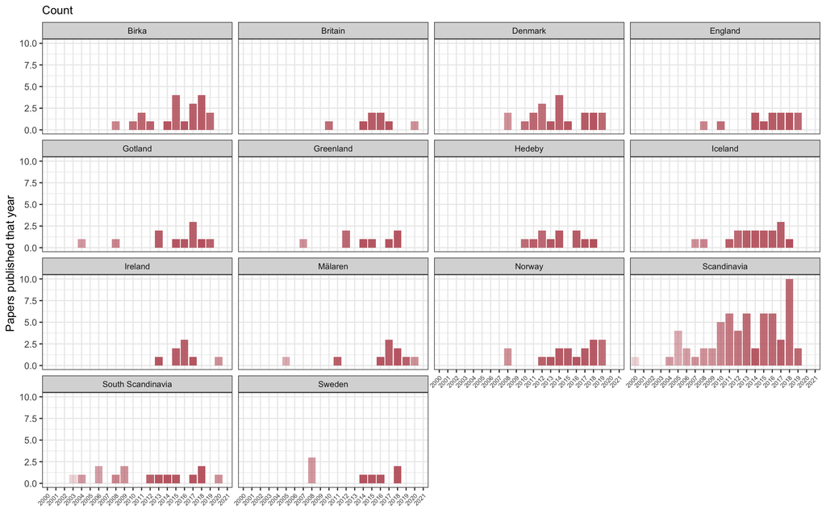

Papers per year, per region (regions with 8+ tagged papers only). Faint bars: few papers that year.

**Enrichment**

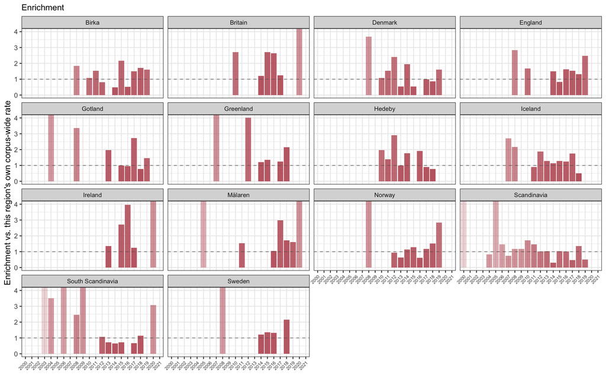

Enrichment per year, per region (regions with 8+ tagged papers only) — that year’s coverage of the region, divided by the region’s own average coverage across the whole corpus (1.0x, dashed line = normal). Faint bars: few papers that year.

**Table**

The numbers behind both charts: one row per region and year. The interval is the Wilson 95% interval on the share of that year’s papers.

| region | year | papers | papers that year | share (%) | enrichment | Wilson 95% low (%) | Wilson 95% high (%) |
| --- | --- | --- | --- | --- | --- | --- | --- |
| Birka | 2000 | 0 | 1 | 0.0 | 0.00 | 0.0 | 79.3 |
| Birka | 2001 | 0 | 1 | 0.0 | 0.00 | 0.0 | 79.3 |
| Birka | 2002 | 0 | 1 | 0.0 | 0.00 | 0.0 | 79.3 |
| Birka | 2003 | 0 | 1 | 0.0 | 0.00 | 0.0 | 79.3 |
| Birka | 2004 | 0 | 7 | 0.0 | 0.00 | 0.0 | 35.4 |
| Birka | 2005 | 0 | 5 | 0.0 | 0.00 | 0.0 | 43.4 |
| Birka | 2006 | 0 | 8 | 0.0 | 0.00 | 0.0 | 32.4 |
| Birka | 2007 | 0 | 8 | 0.0 | 0.00 | 0.0 | 32.4 |
| Birka | 2008 | 1 | 10 | 10.0 | 1.84 | 1.8 | 40.4 |
| Birka | 2009 | 0 | 10 | 0.0 | 0.00 | 0.0 | 27.8 |
| Birka | 2010 | 1 | 17 | 5.9 | 1.09 | 1.0 | 27.0 |
| Birka | 2011 | 2 | 24 | 8.3 | 1.54 | 2.3 | 25.8 |
| Birka | 2012 | 1 | 23 | 4.3 | 0.80 | 0.8 | 21.0 |
| Birka | 2013 | 0 | 34 | 0.0 | 0.00 | 0.0 | 10.2 |
| Birka | 2014 | 1 | 38 | 2.6 | 0.49 | 0.5 | 13.5 |
| Birka | 2015 | 4 | 34 | 11.8 | 2.17 | 4.7 | 26.6 |
| Birka | 2016 | 1 | 35 | 2.9 | 0.53 | 0.5 | 14.5 |
| Birka | 2017 | 3 | 37 | 8.1 | 1.50 | 2.8 | 21.3 |
| Birka | 2018 | 4 | 43 | 9.3 | 1.72 | 3.7 | 21.6 |
| Birka | 2019 | 2 | 23 | 8.7 | 1.60 | 2.4 | 26.8 |
| Birka | 2020 | 0 | 8 | 0.0 | 0.00 | 0.0 | 32.4 |
| Birka | 2021 | 0 | 1 | 0.0 | 0.00 | 0.0 | 79.3 |
| Britain | 2000 | 0 | 1 | 0.0 | 0.00 | 0.0 | 79.3 |
| Britain | 2001 | 0 | 1 | 0.0 | 0.00 | 0.0 | 79.3 |
| Britain | 2002 | 0 | 1 | 0.0 | 0.00 | 0.0 | 79.3 |
| Britain | 2003 | 0 | 1 | 0.0 | 0.00 | 0.0 | 79.3 |
| Britain | 2004 | 0 | 7 | 0.0 | 0.00 | 0.0 | 35.4 |
| Britain | 2005 | 0 | 5 | 0.0 | 0.00 | 0.0 | 43.4 |
| Britain | 2006 | 0 | 8 | 0.0 | 0.00 | 0.0 | 32.4 |
| Britain | 2007 | 0 | 8 | 0.0 | 0.00 | 0.0 | 32.4 |

[output cut: 278 more lines]

### Change over time by country and super-region

Most region tokens are too scattered to show a trend. Countries and super-regions (defined above) group them. A paper counts once toward a country however many of its tokens fall there, and toward every country it names, so the counts do not sum to the corpus. A paper with no country, such as one tagged only with an area name like Scandinavia, counts in every year’s denominator and toward no country. The bars, enrichment and Wilson intervals are built as for Topic, Method and Source, and the threshold is the same 8 papers as for tokens above. A country or super-region with fewer papers is left out. Enrichment is a year’s share of papers divided by the same level’s share across the whole corpus.

**Country**

**Count**

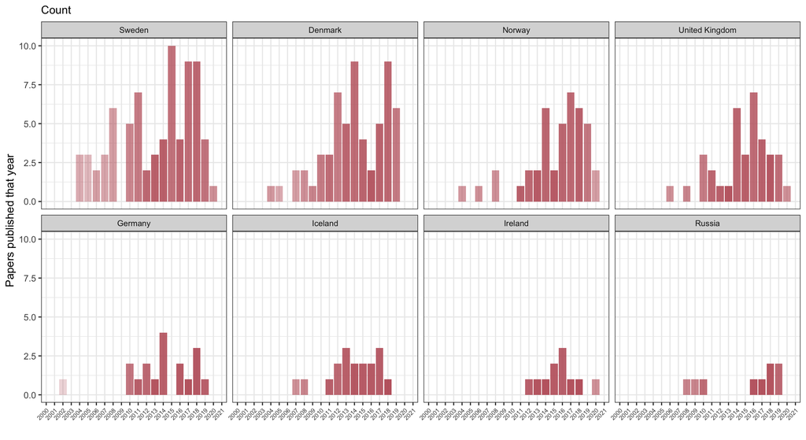

Papers per year. Faint bars: few papers that year.

**Enrichment**

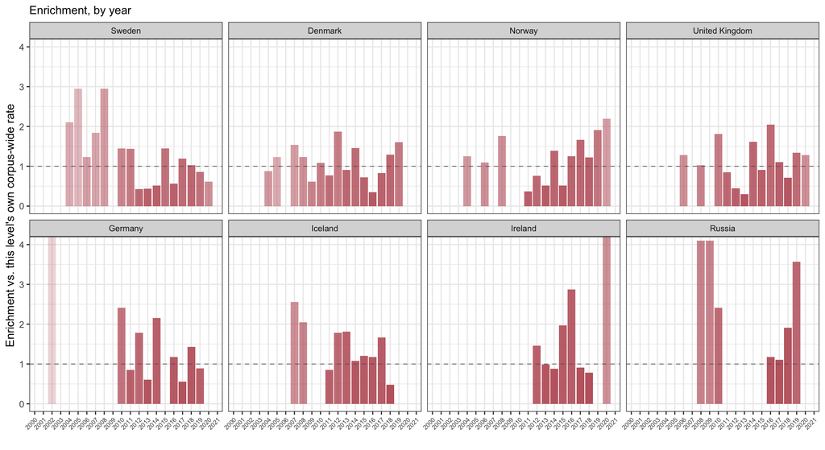

Enrichment per year, as that year’s share of papers divided by the level’s share across the whole corpus (dashed line = 1.0x). Faint bars: few papers that year.

**Smoothed trend**

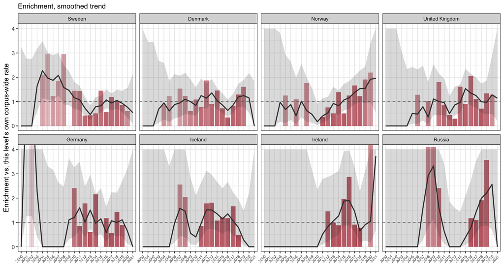

Same enrichment bars, with a 3-year rolling average and its own confidence band.

**Table, by year**

The numbers behind the Count and Enrichment charts: one row per country and year. The interval is the Wilson 95% interval on the share of that year’s papers.

| country | year | papers | papers that year | share (%) | enrichment | Wilson 95% low (%) | Wilson 95% high (%) |
| --- | --- | --- | --- | --- | --- | --- | --- |
| Sweden | 2000 | 0 | 1 | 0.0 | 0.00 | 0.0 | 79.3 |
| Sweden | 2001 | 0 | 1 | 0.0 | 0.00 | 0.0 | 79.3 |
| Sweden | 2002 | 0 | 1 | 0.0 | 0.00 | 0.0 | 79.3 |
| Sweden | 2003 | 0 | 1 | 0.0 | 0.00 | 0.0 | 79.3 |
| Sweden | 2004 | 3 | 7 | 42.9 | 2.11 | 15.8 | 75.0 |
| Sweden | 2005 | 3 | 5 | 60.0 | 2.95 | 23.1 | 88.2 |
| Sweden | 2006 | 2 | 8 | 25.0 | 1.23 | 7.1 | 59.1 |
| Sweden | 2007 | 3 | 8 | 37.5 | 1.84 | 13.7 | 69.4 |
| Sweden | 2008 | 6 | 10 | 60.0 | 2.95 | 31.3 | 83.2 |
| Sweden | 2009 | 0 | 10 | 0.0 | 0.00 | 0.0 | 27.8 |
| Sweden | 2010 | 5 | 17 | 29.4 | 1.45 | 13.3 | 53.1 |
| Sweden | 2011 | 7 | 24 | 29.2 | 1.44 | 14.9 | 49.2 |
| Sweden | 2012 | 2 | 23 | 8.7 | 0.43 | 2.4 | 26.8 |
| Sweden | 2013 | 3 | 34 | 8.8 | 0.43 | 3.0 | 23.0 |
| Sweden | 2014 | 4 | 38 | 10.5 | 0.52 | 4.2 | 24.1 |
| Sweden | 2015 | 10 | 34 | 29.4 | 1.45 | 16.8 | 46.2 |
| Sweden | 2016 | 4 | 35 | 11.4 | 0.56 | 4.5 | 26.0 |
| Sweden | 2017 | 9 | 37 | 24.3 | 1.20 | 13.4 | 40.1 |
| Sweden | 2018 | 9 | 43 | 20.9 | 1.03 | 11.4 | 35.2 |
| Sweden | 2019 | 4 | 23 | 17.4 | 0.86 | 7.0 | 37.1 |
| Sweden | 2020 | 1 | 8 | 12.5 | 0.62 | 2.2 | 47.1 |
| Sweden | 2021 | 0 | 1 | 0.0 | 0.00 | 0.0 | 79.3 |
| Denmark | 2000 | 0 | 1 | 0.0 | 0.00 | 0.0 | 79.3 |
| Denmark | 2001 | 0 | 1 | 0.0 | 0.00 | 0.0 | 79.3 |
| Denmark | 2002 | 0 | 1 | 0.0 | 0.00 | 0.0 | 79.3 |
| Denmark | 2003 | 0 | 1 | 0.0 | 0.00 | 0.0 | 79.3 |
| Denmark | 2004 | 1 | 7 | 14.3 | 0.88 | 2.6 | 51.3 |
| Denmark | 2005 | 1 | 5 | 20.0 | 1.23 | 3.6 | 62.4 |
| Denmark | 2006 | 0 | 8 | 0.0 | 0.00 | 0.0 | 32.4 |
| Denmark | 2007 | 2 | 8 | 25.0 | 1.54 | 7.1 | 59.1 |

[output cut: 146 more lines]

**Table, smoothed**

The numbers behind the Smoothed trend chart. Counts are pooled over a year and its neighbours (fewer at the ends of the range). The interval is computed on the pooled counts and divided by the level’s corpus rate, as plotted.

| country | year | papers in window | all papers in window | smoothed enrichment | Wilson 95% low (enrichment) | Wilson 95% high (enrichment) |
| --- | --- | --- | --- | --- | --- | --- |
| Sweden | 2000 | 0 | 2 | 0.00 | 0.00 | 3.24 |
| Sweden | 2001 | 0 | 3 | 0.00 | 0.00 | 2.76 |
| Sweden | 2002 | 0 | 3 | 0.00 | 0.00 | 2.76 |
| Sweden | 2003 | 3 | 9 | 1.64 | 0.59 | 3.18 |
| Sweden | 2004 | 6 | 13 | 2.27 | 1.14 | 3.49 |
| Sweden | 2005 | 8 | 20 | 1.97 | 1.08 | 3.02 |
| Sweden | 2006 | 8 | 21 | 1.87 | 1.02 | 2.91 |
| Sweden | 2007 | 11 | 26 | 2.08 | 1.26 | 3.00 |
| Sweden | 2008 | 9 | 28 | 1.58 | 0.88 | 2.49 |
| Sweden | 2009 | 11 | 37 | 1.46 | 0.86 | 2.25 |
| Sweden | 2010 | 12 | 51 | 1.16 | 0.69 | 1.81 |
| Sweden | 2011 | 14 | 64 | 1.08 | 0.66 | 1.64 |
| Sweden | 2012 | 12 | 81 | 0.73 | 0.43 | 1.19 |
| Sweden | 2013 | 9 | 95 | 0.47 | 0.25 | 0.84 |
| Sweden | 2014 | 17 | 106 | 0.79 | 0.50 | 1.19 |
| Sweden | 2015 | 18 | 107 | 0.83 | 0.54 | 1.23 |
| Sweden | 2016 | 23 | 106 | 1.07 | 0.73 | 1.50 |
| Sweden | 2017 | 22 | 115 | 0.94 | 0.64 | 1.34 |
| Sweden | 2018 | 22 | 103 | 1.05 | 0.72 | 1.49 |
| Sweden | 2019 | 14 | 74 | 0.93 | 0.57 | 1.44 |
| Sweden | 2020 | 5 | 32 | 0.77 | 0.34 | 1.56 |
| Sweden | 2021 | 1 | 9 | 0.55 | 0.10 | 2.14 |
| Denmark | 2000 | 0 | 2 | 0.00 | 0.00 | 4.04 |
| Denmark | 2001 | 0 | 3 | 0.00 | 0.00 | 3.45 |
| Denmark | 2002 | 0 | 3 | 0.00 | 0.00 | 3.45 |
| Denmark | 2003 | 1 | 9 | 0.68 | 0.12 | 2.68 |
| Denmark | 2004 | 2 | 13 | 0.95 | 0.27 | 2.60 |
| Denmark | 2005 | 2 | 20 | 0.62 | 0.17 | 1.85 |
| Denmark | 2006 | 3 | 21 | 0.88 | 0.31 | 2.13 |
| Denmark | 2007 | 4 | 26 | 0.95 | 0.38 | 2.06 |

[output cut: 146 more lines]

**Super-region**

**Count**

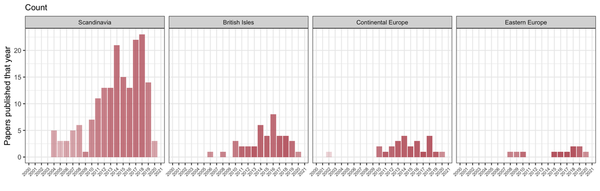

Papers per year. Faint bars: few papers that year.

**Enrichment**

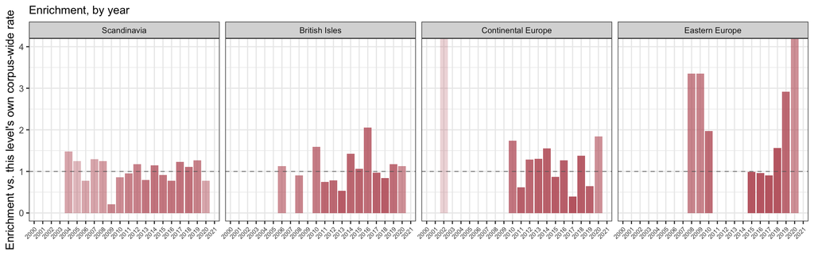

Enrichment per year, as that year’s share of papers divided by the level’s share across the whole corpus (dashed line = 1.0x). Faint bars: few papers that year.

**Smoothed trend**

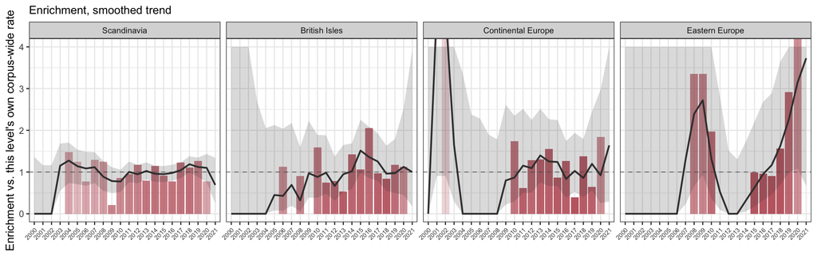

Same enrichment bars, with a 3-year rolling average and its own confidence band.

**Table, by year**

The numbers behind the Count and Enrichment charts: one row per super-region and year. The interval is the Wilson 95% interval on the share of that year’s papers.

| super_region | year | papers | papers that year | share (%) | enrichment | Wilson 95% low (%) | Wilson 95% high (%) |
| --- | --- | --- | --- | --- | --- | --- | --- |
| Scandinavia | 2000 | 0 | 1 | 0.0 | 0.00 | 0.0 | 79.3 |
| Scandinavia | 2001 | 0 | 1 | 0.0 | 0.00 | 0.0 | 79.3 |
| Scandinavia | 2002 | 0 | 1 | 0.0 | 0.00 | 0.0 | 79.3 |
| Scandinavia | 2003 | 0 | 1 | 0.0 | 0.00 | 0.0 | 79.3 |
| Scandinavia | 2004 | 5 | 7 | 71.4 | 1.48 | 35.9 | 91.8 |
| Scandinavia | 2005 | 3 | 5 | 60.0 | 1.24 | 23.1 | 88.2 |
| Scandinavia | 2006 | 3 | 8 | 37.5 | 0.78 | 13.7 | 69.4 |
| Scandinavia | 2007 | 5 | 8 | 62.5 | 1.30 | 30.6 | 86.3 |
| Scandinavia | 2008 | 6 | 10 | 60.0 | 1.24 | 31.3 | 83.2 |
| Scandinavia | 2009 | 1 | 10 | 10.0 | 0.21 | 1.8 | 40.4 |
| Scandinavia | 2010 | 7 | 17 | 41.2 | 0.85 | 21.6 | 64.0 |
| Scandinavia | 2011 | 11 | 24 | 45.8 | 0.95 | 27.9 | 64.9 |
| Scandinavia | 2012 | 13 | 23 | 56.5 | 1.17 | 36.8 | 74.4 |
| Scandinavia | 2013 | 13 | 34 | 38.2 | 0.79 | 23.9 | 55.0 |
| Scandinavia | 2014 | 21 | 38 | 55.3 | 1.15 | 39.7 | 69.9 |
| Scandinavia | 2015 | 15 | 34 | 44.1 | 0.91 | 28.9 | 60.5 |
| Scandinavia | 2016 | 13 | 35 | 37.1 | 0.77 | 23.2 | 53.7 |
| Scandinavia | 2017 | 22 | 37 | 59.5 | 1.23 | 43.5 | 73.7 |
| Scandinavia | 2018 | 23 | 43 | 53.5 | 1.11 | 38.9 | 67.5 |
| Scandinavia | 2019 | 14 | 23 | 60.9 | 1.26 | 40.8 | 77.8 |
| Scandinavia | 2020 | 3 | 8 | 37.5 | 0.78 | 13.7 | 69.4 |
| Scandinavia | 2021 | 0 | 1 | 0.0 | 0.00 | 0.0 | 79.3 |
| British Isles | 2000 | 0 | 1 | 0.0 | 0.00 | 0.0 | 79.3 |
| British Isles | 2001 | 0 | 1 | 0.0 | 0.00 | 0.0 | 79.3 |
| British Isles | 2002 | 0 | 1 | 0.0 | 0.00 | 0.0 | 79.3 |
| British Isles | 2003 | 0 | 1 | 0.0 | 0.00 | 0.0 | 79.3 |
| British Isles | 2004 | 0 | 7 | 0.0 | 0.00 | 0.0 | 35.4 |
| British Isles | 2005 | 0 | 5 | 0.0 | 0.00 | 0.0 | 43.4 |
| British Isles | 2006 | 1 | 8 | 12.5 | 1.12 | 2.2 | 47.1 |
| British Isles | 2007 | 0 | 8 | 0.0 | 0.00 | 0.0 | 32.4 |

[output cut: 58 more lines]

**Table, smoothed**

The numbers behind the Smoothed trend chart. Counts are pooled over a year and its neighbours (fewer at the ends of the range). The interval is computed on the pooled counts and divided by the level’s corpus rate, as plotted.

| super_region | year | papers in window | all papers in window | smoothed enrichment | Wilson 95% low (enrichment) | Wilson 95% high (enrichment) |
| --- | --- | --- | --- | --- | --- | --- |
| Scandinavia | 2000 | 0 | 2 | 0.00 | 0.00 | 1.36 |
| Scandinavia | 2001 | 0 | 3 | 0.00 | 0.00 | 1.16 |
| Scandinavia | 2002 | 0 | 3 | 0.00 | 0.00 | 1.16 |
| Scandinavia | 2003 | 5 | 9 | 1.15 | 0.55 | 1.68 |
| Scandinavia | 2004 | 8 | 13 | 1.28 | 0.74 | 1.71 |
| Scandinavia | 2005 | 11 | 20 | 1.14 | 0.71 | 1.54 |
| Scandinavia | 2006 | 11 | 21 | 1.09 | 0.67 | 1.49 |
| Scandinavia | 2007 | 14 | 26 | 1.12 | 0.74 | 1.48 |
| Scandinavia | 2008 | 12 | 28 | 0.89 | 0.55 | 1.26 |
| Scandinavia | 2009 | 14 | 37 | 0.78 | 0.50 | 1.12 |
| Scandinavia | 2010 | 19 | 51 | 0.77 | 0.52 | 1.06 |
| Scandinavia | 2011 | 31 | 64 | 1.00 | 0.76 | 1.25 |
| Scandinavia | 2012 | 37 | 81 | 0.95 | 0.73 | 1.17 |
| Scandinavia | 2013 | 47 | 95 | 1.03 | 0.82 | 1.23 |
| Scandinavia | 2014 | 49 | 106 | 0.96 | 0.77 | 1.15 |
| Scandinavia | 2015 | 49 | 107 | 0.95 | 0.76 | 1.14 |
| Scandinavia | 2016 | 50 | 106 | 0.98 | 0.79 | 1.17 |
| Scandinavia | 2017 | 58 | 115 | 1.05 | 0.86 | 1.23 |
| Scandinavia | 2018 | 59 | 103 | 1.19 | 0.99 | 1.38 |
| Scandinavia | 2019 | 40 | 74 | 1.12 | 0.89 | 1.35 |
| Scandinavia | 2020 | 17 | 32 | 1.10 | 0.76 | 1.43 |
| Scandinavia | 2021 | 3 | 9 | 0.69 | 0.25 | 1.34 |
| British Isles | 2000 | 0 | 2 | 0.00 | 0.00 | 5.92 |
| British Isles | 2001 | 0 | 3 | 0.00 | 0.00 | 5.05 |
| British Isles | 2002 | 0 | 3 | 0.00 | 0.00 | 5.05 |
| British Isles | 2003 | 0 | 9 | 0.00 | 0.00 | 2.69 |
| British Isles | 2004 | 0 | 13 | 0.00 | 0.00 | 2.05 |
| British Isles | 2005 | 1 | 20 | 0.45 | 0.08 | 2.13 |
| British Isles | 2006 | 1 | 21 | 0.43 | 0.08 | 2.04 |
| British Isles | 2007 | 2 | 26 | 0.69 | 0.19 | 2.17 |

[output cut: 58 more lines]